# No Gut Feelings Bank: positioning the balance sheet for the macro cycle

Tying South African macro scenarios to a bank’s balance sheet, earnings and ROE with public SARB data

Author

Rossouw van Jaarsveld

Published

14 October 2026

R1,431 bn

NGFB total assets at 2026Q2, 15.5% of the reported sector

14.9%

NGFB baseline ROE, three-year average; net income R52.6 bn over three years

12.6% – 16.3%

NGFB ROE from the downside to the upside (net income R43.7 bn to R58.1 bn)

+14 bps

ROE recovered by positioning before the downside (+R654 m of net income); -35 bps if the upside arrives instead

# 1 Summary

**No Gut Feelings Bank (NGFB)** is a fictional South African bank, the size of the average of the six largest banks: R1,431 bn of assets, or 15.5% of the BA900 sector at 2026Q2. It inherits its deposit franchise and structural hedge from the earlier NGFB posts, takes its asset mix from a draw on the six-bank population, and is added to the South African banking sector so that it competes for market share with real peer groups. This report asks four questions of it: *what does a macro scenario do to NGFB’s returns and earnings; how should the balance sheet be positioned before the scenario arrives; where, commercially, should NGFB grow through the cycle; and how should its performance be judged, given the macro environment?*

The framework works top down. Macro variables are tied first to the **banking industry** (Stage 1: 22 sector models of volumes, spreads, deposit costs, credit losses, fees and costs), and only then is a bank tied to the **industry** (Stage 2: market-share dynamics by macro regime, pooled across banks). A quarterly engine turns the result into net interest income, credit losses, capital, liquidity, net income and ROE, and an optimiser translates “scenario X is coming” into balance-sheet moves.

What it finds:

1. **Three scenarios.** Over the next three years NGFB’s ROE averages 14.9% in the **baseline** (net income R52.6 bn, about R17.5 bn a year), 16.3% in the **upside** (faster disinflation and a growth dividend; +R5.5 bn of net income) and 12.6% in the **downside** (a stagflationary shock with SARB hikes and a two-year contraction; -R8.9 bn).
2. **NGFB and the industry move in opposite directions.** The unhedged industry gains from higher rates and loses from lower ones, so its ROE barely moves in the downside (+13 bps) and falls in the upside (-30 bps). NGFB’s structural hedge gives that rate exposure away: in the downside it loses 229 bps, 162 bps through credit losses on its unsecured-heavy book and 72 bps through pricing, because with the refined deposit-cost models the hedge more than offsets its deposit endowment (a 100 bps higher repo path costs hedged NGFB 61 bps of ROE and would add 128 bps unhedged).
3. **Credit is the largest single exposure.** GDP growth one point lower for three years costs 67 bps of ROE (R2,640 m of net income), almost all through credit losses.
4. **Positioning before the downside** cuts the receive-fixed hedge from 49.6% to 42.3% of non-maturity deposits, swaps 0.49% of assets of wholesale funding for retail deposits and trims unsecured lending by 0.46% of assets. It recovers 14 bps of ROE (R654 m of net income over three years) if the downside comes, and costs 14 bps if the baseline does and 35 bps if the upside does. **Before the upside** the moves reverse: extend the hedge to 55.3% and lean into unsecured lending (+8 bps if it comes).
5. **Being more aggressive moves the numbers more, in both directions.** Doubling the optimal moves at the same execution cost wipes out the gain even if the downside arrives and loses 99 bps if the upside does. A bank that can execute four times more cheaply can make 54 bps from the same view, but stands to lose 123 bps if it is wrong. The loss if wrong grows faster than the gain if right.
6. **The downside’s key judgement is the SARB’s response.** If the same contraction came with rate cuts (as in 2009 and 2020), the hedge would be NGFB’s protection rather than its cost, and the optimal hedge move flips sign (+11.4 instead of -7.3 points of NMD); cutting unsecured lending is right in both.
7. **Is ARDL the right tool?** Yes, refined. Six checks found two improvements worth adopting, a richer short-run response of deposit costs to the repo rate and asymmetric pass-through where hikes and cuts demonstrably differ (savings deposits and card yields), and one worth reporting as a sensitivity (credit losses that rise faster in a contraction than they fall in a boom). BIC-weighted model averaging beat both alternatives tried against it. The refinements lower the baseline ROE from 16.1% in the previous version to 14.9%, because deposit costs reprice faster than the earlier models assumed.
8. **Monthly data do not fit better, except for the lumpiest books.** With quarterly GDP, unemployment and house prices turned monthly by the Kalman filter (the monthly GDP path nowcasts the quarter with an error of 2.1 pp against 2.7 pp for an AR(1)), monthly satellites on every month of BA900, BA100 and BA120 forecast the same quarterly outcomes less accurately than the quarterly ones: the median monthly error is 1.20 times the quarterly in pricing and 1.05 times in volumes. Corporate loans and term deposits are the exception, forecast significantly better monthly because a monthly model sees when in the quarter a large flow arrived, which argues for a monthly nowcast of the jump-off book rather than for monthly scenario models; production stays quarterly. The sign-restricted ARDL remains the best macro model at either frequency, and its sign restrictions matter most for volumes: left free, the home-loan model puts all of its weight on a *positive* response to rate hikes, because the SARB raises rates into credit booms. Monthly multipliers show the first weeks of a rate cycle that quarterly models cannot: call deposits reprice 59 bps within two months of a 100 bps rise.
9. **NGFB under-participates in easing cycles.** When rates fall, the card, corporate-loan and vehicle-finance markets grow fastest and NGFB’s share of each falls, the card share going to the Challengers. Pushing cards pays even on wholesale funding; corporate lending clears the bar only narrowly on wholesale funding and vehicle finance barely at all, but both pay comfortably if they bring their own deposits. In a contraction NGFB *gains* card share while the market stalls, a guard case: the extra book pays only if it loses no more than 0.8 pp a year above the average card loss rate.
10. **Macro-adjusted scorecards separate the tide from the swimming.** Against the large-bank population, NGFB is near the frontier in cards in the downside (77% percentile) but below par in home loans (34%), because a typical large bank gains mortgage share in a contraction; in the upside it is below par in cards, corporate loans and vehicle finance – exactly where the upside’s growth is.

Three-year averages (net income: totals), 2026Q3 to 2029Q2. The sector is the BA900 industry run through the same engine without a structural hedge. The downside with cuts is a model-risk variant, not a fourth scenario.

| Scenario | NGFB ROE | vs baseline | NGFB net income, 3 years | vs baseline | NGFB, unhedged ROE | Sector ROE | NGFB NIM | NGFB credit-loss ratio | CET1 trough |
| --- | --- | --- | --- | --- | --- | --- | --- | --- | --- |
| Baseline | 14.9% | +0 bps | R52.6 bn | +R0.0 bn | 10.7% | 14.5% | 3.37% | 1.40% | 13.0% |
| Upside | 16.3% | +138 bps | R58.1 bn | +R5.5 bn | 10.9% | 14.2% | 3.41% | 1.23% | 13.1% |
| Downside | 12.6% | -229 bps | R43.7 bn | -R8.9 bn | 9.9% | 14.7% | 3.27% | 1.62% | 12.8% |
| Downside with cuts | 13.8% | -109 bps | R48.3 bn | -R4.3 bn | 7.2% | 11.5% | 3.40% | 1.58% | 13.0% |

**What changed from the previous version**

This version adds three chapters: monthly frequency (the Kalman filter for quarterly macro series, a monthly-against-quarterly horse race, how the lags and sign restrictions work, and dynamic multipliers), market-share strategy and macro-adjusted performance. Monthly estimation was tested and not adopted, so the quarterly models, the scenarios and the positioning are unchanged from the previous version, in which the refined deposit-cost models moved NGFB’s baseline ROE from 16.1% to 14.9% (section Is ARDL the right tool?).

# 2 The question and the design

A bank’s ALCO typically asks three things of a macro outlook: *how exposed are we*, *what does scenario X do to our returns*, and *what should we do before it arrives*. Answering them from public data needs a chain from macro variables to a bank’s balance sheet. The weak link in most attempts is the last one: a single bank’s history is short, noisy and full of idiosyncratic events (acquisitions, strategy changes, one-off provisions), so regressing a bank’s metrics directly on macro variables tends to produce elasticities that are unstable and sometimes the wrong sign.

The design here estimates the macro relationships **once, on the industry**, where they are best identified, and then models a bank **relative to the industry**. For any product $p$ the identity

$$g^{\text{bank}}_{p,t} = g^{\text{sector}}_{p,t} + \Delta \log s_{p,t}$$

splits a bank’s growth into the sector’s growth, which Stage 1 explains with macro variables, and the change in its market share, which Stage 2 explains with the macro *regime* and the sector cycle. The macro elasticities the bank inherits are therefore the sector’s; the bank layer only has to say whether the bank gains or loses ground, and when.

```
flowchart TB
  M["<b>Macro scenario</b><br/>repo, curve, GDP, CPI, unemployment,<br/>house prices, rand, equities"] --> S1["<b>Stage 1: macro to the industry</b><br/>sign-restricted ARDL models,<br/>dynamic out-of-sample selection, BMA"]
  S1 --> SEC["<b>Industry paths</b><br/>volumes, spreads, deposit costs,<br/>credit losses, fees, costs"]
  SEC --> S2["<b>Stage 2: banks relative to the industry</b><br/>market-share dynamics by regime,<br/>pooled across banks, NGFB drawn"]
  S2 --> NG["<b>NGFB balance sheet</b><br/>embedded in the industry"]
  SEC --> ENG["<b>Engine</b><br/>NII, hedge, credit losses, NIR, opex,<br/>tax, capital, liquidity, net income, ROE"]
  NG --> ENG
  ENG --> OUT["<b>Answers</b><br/>scenario ROE and net income, sensitivities,<br/>positioning before the scenario arrives"]
```

[output not shown]

Each piece is a module of the `baeconstrat` package (structured as an R package with separate scripts for each step; see Reproducing the analysis):

Pipeline. Every number in this report is read from the `output/*.rds` files and checked with `guard()` before it is printed.

| Step | Package code | Script | Output |
| --- | --- | --- | --- |
| Data pull (SARB API, FRED) | `sarb_api.R`, `sarb_forms.R`, `sarb_macro.R`, `fred.R`, `pull.R` | `data-raw/01_pull_data.R` | `data-raw/` caches |
| Panels and peer groups | `map_ba900.R`, `map_sector.R`, `panel_bank.R`, `panel_macro.R`, `liquidity.R` | `analysis/01_build_panels.R` | `panels.rds` |
| Stage 1 | `ols_hac.R`, `satellite.R`, `industry_models.R`, `pipeline.R` | `analysis/02_stage1.R` | `stage1.rds` |
| Stage 2 | `bank_relative.R`, `hierarchy.R` | `analysis/03_stage2.R` | `stage2.rds` |
| NGFB | `ngfb.R`, `calibration.R` | `analysis/04_ngfb.R` | `ngfb.rds` |
| Scenarios and sensitivities | `scenarios.R`, `projection.R`, `pnl_engine.R`, `attribution.R` | `analysis/05_scenarios.R` | `scenarios.rds` |
| Positioning | `optimise.R` | `analysis/06_optimise.R` | `optimise.rds` |
| Back-test | — | `analysis/07_backtest.R` | `backtest.rds` |
| Model checks | `model_checks.R` | `analysis/08_model_checks.R` | `model_checks.rds` |

# 3 Data

Everything is public. The SARB’s BA returns come through its web API (`custom.resbank.co.za/SarbWebApi`), with the existing pull harness in this project; macro series come from the SARB’s key-indicator releases and from FRED.

Data sources.

| Source | What it gives | Coverage used |
| --- | --- | --- |
| **BA900** (economic return), per bank | balance sheet by product and counterparty; deposits by depositor and contractual bucket | 75 periods, Mar 2008 to Jul 2026; 21 institutions including the sector total |
| **BA100 / BA120** (sector only) | balance sheet and income statement: interest by product, fees, costs, impairments, tax | monthly to Jun 2025 |
| **BA200 / BA700** (sector only) | credit risk-weighted exposure by asset class; capital adequacy, RWA, CET1 | to Jun 2025 |
| SARB key indicators | repo, prime, long bond yield, CPI, rand, JSE All Share, business-cycle indicators, private credit | to 2026Q3 |
| FRED (OECD, BIS, Stats SA via FRED) | real GDP, unemployment, house prices, 3-month JIBAR, 10-year yield, household debt | real GDP to 2026Q1 |
| Prudential Authority, *Selected South African banking sector trends* (June 2025) | sector LCR 149.59%, NSFR 117.29%, CET1 13.25% | calibration targets |
| SARB Monetary Policy Committee statements | repo at 7.00% after May 2026 and 7.25% after 24 September 2026; inflation above 5% around the turn of the year, back at the 3% target by late 2027 | baseline policy and inflation path |

Three properties of the data shape everything that follows.

- **Only BA900 is published per bank.** Income statements, capital and liquidity exist only for the sector (BA1xx, BA200, BA700). This is the practical reason for the two-stage design: bank-level information is balance-sheet volumes; prices, losses and costs are sector-level.
- **The sector returns end in June 2025; BA900 runs to mid-2026.** Sector margins and losses are therefore “nowcast” through the four missing quarters from realised macro data before any scenario starts.
- **Real banks are only ever shown pooled.** Every peer group has at least 4 members in every quarter (k-anonymity of at least four), and the six large banks enter NGFB only through population hyperparameters and pooled averages.

BA900 is internally consistent: across all banks and periods the product lines reproduce reported total assets and total liabilities to within 2.6e-05 (relative). The depositor-by-bucket deposit matrix used for the liquidity proxies adds up exactly to the behavioural deposit lines.

## 3.1 Who is in each peer group

Named banks by peer group. Members per quarter: Big Four 4 to 5, Challengers 4 to 7, Specialists 5 to 8. Corporate history as publicly reported (see the sources at the end). Membership only: no result in this report is shown for an individual bank.

| Group | Bank | In the BA900 data | Who they are |
| --- | --- | --- | --- |
| Big Four | Absa Bank | throughout | Universal bank; part of Barclays Africa Group until Barclays cut its stake to 14.9% in 2017, after which the group took the Absa name (2018). |
| Big Four | FirstRand Bank | throughout | Universal bank operating as FNB (retail and commercial), RMB (corporate and investment banking) and WesBank (vehicle and asset finance). |
| Big Four | Imperial Bank | 2008Q1 to 2010Q3 | Vehicle and asset finance bank founded by Imperial Holdings in 1996; Nedbank held 50.1% from 2001 and bought the rest in 2009. Its return ends in 2010Q3 and the book continues inside Nedbank, so it is… |
| Big Four | Nedbank | throughout | Universal bank with a large corporate and commercial-property book; Old Mutual distributed most of its majority stake to shareholders in its 2018 managed separation. |
| Big Four | The Standard Bank of South Africa | throughout | The largest bank by assets; China’s ICBC has held 20% of Standard Bank Group since March 2008. |
| Challengers | African Bank | throughout | Unsecured lender placed under curatorship in August 2014 and relaunched in April 2016; has since bought Grindrod Bank (agreed 2022), most of Ubank (2022) and Sasfin’s equipment- and property-finance b… |
| Challengers | Capitec Bank | throughout | Retail bank founded in 2001 on low-cost transactional banking and unsecured lending; now the largest retail bank by number of clients. Grouped with the challengers for its growth path and business mod… |
| Challengers | Mercantile Bank | 2008Q1 to 2022Q1 | Business bank bought by Capitec from Caixa Geral de Depósitos in November 2019 (R3.56 bn); its return ends in 2022Q1 as the business moved into Capitec. |
| Challengers | Ubank | 2008Q1 to 2024Q2 | Formerly Teba Bank, serving mining communities; placed under curatorship in May 2022 and most of its book taken over by African Bank from November 2022; return ends 2024Q2. |
| Challengers | Discovery Bank | 2016Q4 to 2026Q2 | Banking arm of the insurer Discovery; launched in late 2018 and opened to clients in 2019 (its return starts in 2016Q4, before launch). |
| Challengers | TymeBank | 2018Q1 to 2026Q2 | Digital bank licensed in 2017 as TymeDigital under Commonwealth Bank of Australia, sold to African Rainbow Capital in 2018; rebranded GoTyme Bank in January 2026. |
| Challengers | Bank Zero | 2020Q1 to 2026Q2 | Digital mutual bank registered in 2018 and launched in 2021; Lesaka agreed to buy it in 2025, subject to approval. |
| Specialists | Albaraka Bank | throughout | Islamic bank, part of the Bahrain-based Al Baraka banking group. |
| Specialists | Bidvest Bank | throughout | Part of the Bidvest group: foreign exchange, fleet and business banking. A sale to Access Bank agreed in December 2024 lapsed in January 2026. |
| Specialists | Grindrod Bank | 2008Q1 to 2024Q2 | Business bank owned by the Grindrod logistics group until African Bank agreed to buy it in May 2022 (R1.5 bn); its return ends in 2024Q2. |
| Specialists | Habib Overseas Bank | throughout | Small bank licensed in 1990, unrelated to HBZ; placed under curatorship in March 2023. |
| Specialists | HBZ Bank | throughout | Subsidiary of Habib Bank AG Zurich (Switzerland). |
| Specialists | Investec Bank | throughout | Specialist bank and wealth manager for private clients and corporates; part of the Investec group, listed in Johannesburg and London. |
| Specialists | Sasfin Bank | 2008Q1 to 2026Q1 | Business bank (equipment and trade finance). It sold its equipment- and property-finance books to African Bank, closed its business bank by the end of 2025 and is deregistering its licence; its return… |
| Specialists | Access Bank South Africa | 2018Q1 to 2026Q2 | The former Bank of Athens (South Africa), bought by Grobank in 2018 and renamed Grobank in 2019, then controlled by Nigeria’s Access Bank from 2021. Its pre-2018 returns (The S A Bank of Athens) were … |

**Other** is the residual: the BA900 sector total less every named bank, between 15 and 21 institutions a quarter. Two of its members are worth flagging: the pre-2018 returns of the bank that became Access Bank South Africa (the S A Bank of Athens), and OM Bank, Old Mutual’s new bank, which reports from 2025Q1 under a name the pull’s patterns did not match. Both sit in Other in this data; the patterns now match them, so a fresh pull would move them to their groups. Postbank does not appear in the BA900 listings.

Members of Other in the SARB’s BA900 institution listings, 2008–2026 (years in brackets where an institution was not listed throughout).

| Kind | Institutions |
| --- | --- |
| Foreign bank branches | Bank of Baroda (2008–2020); Bank of China; Bank of Communications (2020–2026); Bank of India (2013–2020); Bank of Taiwan; BNP Paribas (2013–2024); Canara Bank (2008–2020); China Construction Bank; Cit… |
| Mutual banks | ENL Mutual Bank (2024–2026); Finbond Mutual Bank (2012–2026); GBS Mutual Bank; VBS Mutual Bank |
| Small or new banks not pulled | Commonwealth Bank of South Africa (2016–2017); Ithala (2022–2023); MEEG Bank (2008–2009); OM Bank (Old Mutual) (2025–2026); Regal Treasury Private Bank (2008–2009); S A Bank of Athens (2008–2017) |

The grouping follows business model and growth path rather than size alone. The **Big Four** are the universal banks that have dominated South African banking for decades. The **Challengers** are the retail and digital banks that have taken market share from them since 2008, Capitec above all; Capitec is now the largest retail bank by number of clients, but its balance sheet, funding and growth pattern are a challenger’s, so it is grouped there. The **Specialists** are niche business, private-client, Islamic and community banks. Imperial Bank is counted with the Big Four because Nedbank owned it and its book continued inside Nedbank (the pro-forma treatment keeps the group’s history free of an artificial jump in 2010).

# 4 NGFB: the bank

## 4.1 What is canonical, and what is new

NGFB carries over everything the earlier posts fixed, and extends the bank to a full balance sheet with the same rule the deposit posts used: a typical large South African bank drawn from the population, never a copy of any one of them.

NGFB’s identity. The deposit block, leverage and hedge are checked against the canonical constants before anything is computed.

| Item | Value | Origin |
| --- | --- | --- |
| Seed | 20260622 | Post 1 |
| Deposit mix: operational / notice / savings / term | 41.7% / 10.8% / 7.5% / 39.9% | Post 1 canonical draw (`ngfb_composition_canonical.csv`) |
| Deposit betas (one-month slopes) | 0.463 / 0.625 / 0.463 / 0.245 | Post 1 |
| Interest-earning assets / equity | 12.36 | Post 3 BA100 bridge |
| All deposits / interest-earning assets | 0.893 | Post 3 BA100 bridge |
| Structural hedge | 49.6% of NMD, receive-fixed, 5-year rolling boxcar | Post 3 optimum |
| Size | mean total assets of the six large banks: R1,431 bn | new |
| Asset composition | business-line draw from the six-bank population | new |
| Other funding | the population’s mix of repo, wholesale and other liabilities | new |

**A note on Post 2’s weights**

Post 2 loaded `post1_betas.rds`, whose weights (23.9 / 8.9 / 23.4 / 43.7) are an older draw. The canonical composition is the one Post 1 published and Post 4 used (41.7 / 10.8 / 7.5 / 39.9), and that is what NGFB carries here.

## 4.2 The asset draw

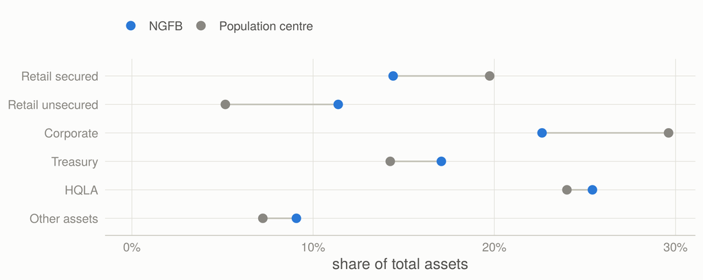

NGFB’s business-line mix against the population centre. The draw lands on the unsecured-heavy side of the six banks: inside the truncation radius, but more than twice the centre’s unsecured share.

```r
ad <- N$asset_draw
bl_lab <- c(retail_secured = "Retail secured", retail_unsecured = "Retail unsecured",
            corporate = "Corporate", treasury = "Treasury", hqla = "HQLA", other = "Other assets")
dd <- data.frame(line = factor(bl_lab[names(ad$line_draw)], levels = rev(bl_lab)),
                 NGFB = as.numeric(ad$line_draw), centre = as.numeric(ad$line_mean[names(ad$line_draw)]))
guard(abs(sum(dd$NGFB) - 1) < 1e-10 && abs(sum(dd$centre) - 1) < 1e-10, "composition shares do not sum to one")
dl <- rbind(data.frame(line = dd$line, who = "NGFB", share = dd$NGFB),
            data.frame(line = dd$line, who = "Population centre", share = dd$centre))
ggplot(dd, aes(y = line)) +
  geom_segment(aes(x = centre, xend = NGFB, yend = line), colour = ink[["axis"]], linewidth = 0.6) +
  geom_point(data = dl, aes(x = share, colour = who), size = 3) +
  scale_colour_manual(values = c(NGFB = ent_col[["NGFB"]], `Population centre` = ink[["muted"]])) +
  scale_x_continuous(labels = scales::percent_format(1), limits = c(0, NA)) +
  labs(x = "share of total assets", y = NULL)
```

**Table view**

| Business line | NGFB | Population centre |
| --- | --- | --- |
| Retail secured | 14.4% | 19.7% |
| Retail unsecured | 11.4% | 5.2% |
| Corporate | 22.6% | 29.6% |
| Treasury | 17.1% | 14.3% |
| HQLA | 25.4% | 24.0% |
| Other assets | 9.1% | 7.2% |

Six banks cannot identify an eleven-dimensional covariance of product shares, so the draw is made over six business lines (five dimensions in additive log-ratio space) from a logistic-normal fitted to the six banks’ average compositions over the last eight quarters, and products are split within each line at the population’s average within-line mix. The draw is truncated to the same central probability mass as Post 1’s composition draw (radius 1 in three dimensions keeps the central 19.9%; the equivalent radius in five dimensions is 1.53). NGFB’s draw sits at Mahalanobis distance 0.95.

The seed puts NGFB on the unsecured side of the population: retail unsecured lending is 11.4% of assets against the centre’s 5.2%. That is a legitimate member of the population (one of the six is an unsecured specialist), and it is kept because the seed is canonical, but it colours every result: NGFB’s credit-loss ratio is higher than the sector’s, and it is more exposed to the credit cycle.

## 4.3 The balance sheet

NGFB’s jump-off balance sheet at 2026Q2 against the BA900 sector.

| Line | Side | NGFB, R bn | NGFB, % of assets | Sector, % of assets | NGFB share of augmented sector |
| --- | --- | --- | --- | --- | --- |
| Residential mortgages | asset | 141 | 9.9% | 15.3% | 9.1% |
| Vehicle and asset finance | asset | 65 | 4.5% | 7.6% | 8.5% |
| Credit cards | asset | 69 | 4.8% | 2.1% | 26.0% |
| Personal and other retail | asset | 94 | 6.5% | 3.3% | 23.4% |
| Corporate loans | asset | 199 | 13.9% | 18.5% | 10.5% |
| Overdrafts | asset | 40 | 2.8% | 3.3% | 11.6% |
| Commercial mortgages | asset | 85 | 5.9% | 6.5% | 12.3% |
| Interbank | asset | 69 | 4.8% | 4.8% | 13.5% |
| Reverse repo | asset | 130 | 9.1% | 7.3% | 16.2% |
| Other securities | asset | 45 | 3.1% | 2.3% | 17.2% |
| HQLA (cash, central bank, government) | asset | 364 | 25.4% | 21.7% | 15.4% |
| Other assets | asset | 130 | 9.1% | 7.2% | 16.4% |
| Operational deposits | funding | 485 | 33.9% | 34.9% | 13.1% |
| Notice deposits | funding | 125 | 8.8% | 4.9% | 21.7% |
| Savings deposits | funding | 88 | 6.1% | 6.5% | 12.7% |
| Term deposits | funding | 464 | 32.4% | 22.2% | 18.5% |
| Repo funding | funding | 32 | 2.2% | 3.6% | 8.7% |
| Wholesale and other funding | funding | 85 | 6.0% | 15.1% | 5.8% |
| Other liabilities | funding | 47 | 3.3% | 5.3% | 8.7% |
| Equity | equity | 105 | 7.4% | 7.4% | 13.3% |

## 4.4 NGFB in the industry

NGFB is **added** to the industry rather than carved out of existing banks, following the Post 1 convention of adding a bank the size of the average large bank. Reported banks keep their own books; market shares are measured against the augmented industry, the reported sector plus NGFB. NGFB’s history is back-cast from its jump-off book with its drawn share-dynamics parameters (Stage 2) and the realised regimes and sector growth, so it “lives through” 2008–2026 the way a bank with those parameters would have.

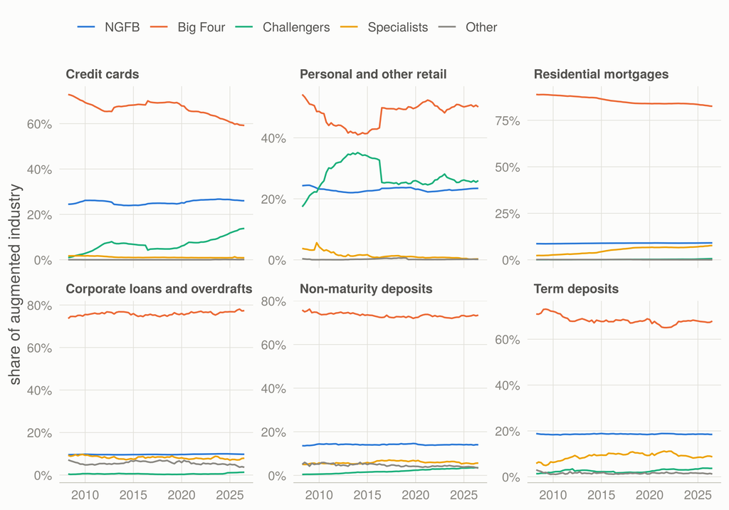

Market shares of the augmented industry (reported sector plus NGFB). NGFB’s line is its back-cast; the peer groups are reported BA900 data.

```r
show_p <- c(cards = "Credit cards", personal_other = "Personal and other retail", mortgages_res = "Residential mortgages",
            corp_all = "Corporate loans and overdrafts", nmd = "Non-maturity deposits", beh_term = "Term deposits")
sh <- N$shares[N$shares$product %in% names(show_p), ]
sh$product <- factor(show_p[sh$product], levels = show_p)
sh$entity <- factor(sh$entity, levels = names(ent_col))
ggplot(sh, aes(date, share, colour = entity)) +
  geom_line(linewidth = 0.6) +
  facet_wrap(~ product, ncol = 3, scales = "free_y") +
  scale_colour_manual(values = ent_col) +
  scale_y_continuous(labels = scales::percent_format(1)) +
  labs(x = NULL, y = "share of augmented industry")
```

**Table view**

| product | entity | 2008Q2 | 2016Q2 | 2026Q2 |
| --- | --- | --- | --- | --- |
| Corporate loans and overdrafts | Big Four | 74.6% | 75.3% | 77.4% |
| Corporate loans and overdrafts | Challengers | 0.3% | 0.5% | 1.3% |
| Corporate loans and overdrafts | NGFB | 9.6% | 9.7% | 9.8% |
| Corporate loans and overdrafts | Other | 6.7% | 6.2% | 3.6% |
| Corporate loans and overdrafts | Specialists | 8.8% | 8.4% | 7.9% |
| Credit cards | Big Four | 72.6% | 70.0% | 59.2% |
| Credit cards | Challengers | 1.1% | 4.3% | 13.8% |
| Credit cards | NGFB | 24.5% | 24.7% | 26.0% |
| Credit cards | Other | 0.0% | 0.0% | 0.1% |
| Credit cards | Specialists | 1.7% | 1.0% | 0.9% |
| Non-maturity deposits | Big Four | 75.0% | 72.4% | 73.4% |
| Non-maturity deposits | Challengers | 0.5% | 1.7% | 3.5% |
| Non-maturity deposits | NGFB | 13.6% | 14.2% | 14.0% |
| Non-maturity deposits | Other | 6.0% | 4.9% | 3.3% |
| Non-maturity deposits | Specialists | 5.0% | 6.9% | 5.7% |
| Personal and other retail | Big Four | 53.4% | 49.8% | 50.1% |
| Personal and other retail | Challengers | 18.4% | 25.4% | 26.0% |
| Personal and other retail | NGFB | 24.4% | 23.4% | 23.4% |
| Personal and other retail | Other | 0.3% | 0.5% | 0.2% |
| Personal and other retail | Specialists | 3.6% | 0.9% | 0.3% |
| Residential mortgages | Big Four | 88.8% | 85.3% | 82.6% |
| Residential mortgages | Challengers | 0.1% | 0.2% | 0.6% |
| Residential mortgages | NGFB | 8.7% | 9.0% | 9.1% |
| Residential mortgages | Other | 0.1% | 0.2% | 0.0% |
| Residential mortgages | Specialists | 2.3% | 5.4% | 7.7% |
| Term deposits | Big Four | 70.9% | 68.4% | 67.9% |
| Term deposits | Challengers | 1.4% | 1.7% | 3.7% |
| Term deposits | NGFB | 18.7% | 18.7% | 18.5% |
| Term deposits | Other | 2.6% | 1.3% | 1.2% |
| Term deposits | Specialists | 6.4% | 9.9% | 8.7% |

At the jump-off NGFB holds 26% of the augmented industry’s credit cards and 23% of personal loans, against 9% of residential mortgages. A bank the size of the average large bank with an unsecured-heavy mix is necessarily a large card and personal lender; this is the consequence of the canonical seed noted above, not a forecast.

## 4.5 Calibration to the sector

The engine prices loans and deposits with the sector’s own BA120 yields and costs (projected by Stage 1), applies the sector’s credit-loss ratio through relative loss multipliers by product, and the sector’s fee and cost ratios. The remaining free parameters are pinned to the sector at the last BA120 quarter, 2025Q2:

Calibration to the sector.

| Parameter | Value | How it is set |
| --- | --- | --- |
| Credit risk-weight scale | 1.131 | BA900 sector book × BA200 asset-class risk weights reproduces BA200 credit RWA |
| Non-credit RWA | 11.6% of assets | BA700 total RWA less BA200 credit RWA |
| CET1 / book equity | 0.809 | BA700 CET1 over BA100 ordinary equity |
| Effective tax rate | 22.0% | BA120, last three years |
| HQLA earning share | 80.2% | 1 − cash and central-bank balances / HQLA (BA100) |
| Wholesale spread over JIBAR | 1.17 pp | solved: engine NII = BA120 NII over 2024Q3–2025Q2 (R249 bn) |
| LCR run-off scalar | 0.798 | solved: sector LCR proxy = 149.6% (Prudential Authority, June 2025) |
| NSFR required-funding scalar | 0.924 | solved: sector NSFR proxy = 117.3% |

Two checks are worth stating plainly. First, the engine’s *gross* interest income and expense on the BA900 balance sheet come out 12% and 20% above BA120’s, while NII matches with a plausible wholesale spread. BA900 carries trading-book positions on both sides of the balance sheet whose interest BA120 books in trading revenue (its own “allocated to trading” lines are R41 bn of expense and R10 bn of income over the window), so the excess is close to net-neutral and is reported rather than calibrated away. Second, one quarter of BA120 call-deposit cost (2025Q2, 10.5%) is a one-off outlier that the Stage 1 impulse dummies flag; it is replaced by the window median before calibrating. Left in, it drives the solved wholesale spread to JIBAR -0.26 pp (see What didn’t work).

### 4.5.1 Liquidity

Depositor-weighted Basel III factors by behavioural deposit line, before the sector scalars. Depositor shares are the sector’s at the calibration date.

| Line | Financial depositors | Retail depositors | 30-day run-off, sector | 30-day run-off, NGFB pool | ASF, sector | ASF, NGFB pool |
| --- | --- | --- | --- | --- | --- | --- |
| Operational deposits | 23% | 31% | 32.8% | 33.6% | 56% | 56% |
| Savings deposits | 2% | 75% | 18.5% | 18.8% | 79% | 79% |
| Notice deposits | 28% | 21% | 50.8% | 48.9% | 44% | 46% |
| Term deposits | 59% | 28% | 8.9% | 9.1% | 65% | 64% |

BA900 crosses depositors with contractual buckets, and the Basel III run-off and stable-funding factors depend on both, so each behavioural deposit line carries the balance-weighted factor of the depositors who hold it: fund managers’ call money runs off at 100% inside 30 days, household savings at 10%. Unadjusted, these proxies put the sector’s LCR at 112% and NSFR at 108% against the published 150% and 117%; one scalar each absorbs what BA900 cannot see (the 30-day slice of term deposits, operational status, committed facilities, derivatives). NGFB, with more HQLA and less wholesale funding than the sector, starts at an LCR of 190% and an NSFR of 132%.

# 5 Stage 1: macro to the industry

## 5.1 Method

Each sector target $y$ (a product’s volume growth, a spread over its reference rate, a deposit cost, the credit-loss ratio, fee income or costs over assets) gets an autoregressive distributed-lag (ARDL) model

$$y_t = c + \rho\, y_{t-1} + \sum_j \beta_j\, x_{j,t-l_j} + \varepsilon_t ,$$

chosen by a disciplined search rather than by hand:

1. every subset of up to 3 macro drivers, at most one per economic group, each at one lag in 0–4 quarters;
2. a specification survives only if every driver carries its a-priori sign in the short run **and** in the long-run multiplier $\beta/(1-\rho)$, with a Newey–West $|t| \ge 1$ and $|\rho| < 0.98$;
3. survivors are ranked by **dynamic** pseudo-out-of-sample RMSE: from each expanding-window origin (the first after 28 quarters) the model is re-estimated and simulated 4 quarters ahead on the realised macro path, which is how a scenario uses it; an AR(1) is the benchmark;
4. the projection averages all sign-valid specifications with BIC weights (Bayesian model averaging), which gives each driver a posterior inclusion probability (PIP) and a model-averaged long-run multiplier.

Deposit-cost models must contain the repo rate, so their long run is anchored to it, and may also contain its quarterly change, so the impact of a rate move and its long-run pass-through are estimated separately (an ARDL(1,1)). For savings deposits the repo rate enters as two partial sums, of increases and of decreases, so that hikes and cuts can pass through differently. Both refinements were adopted after the tests in the next section. One-off outliers (AR(1) innovations beyond four MADs) get impulse dummies; the two COVID quarters get dummies in the volume models only, so the credit-loss models keep the 2020 stress signal. Ratio targets (pricing, credit, fees and costs) carry an intercept correction: the mean residual of the last four unflagged quarters shifts the projected path, which protects against structural drift the sample average does not know about.

## 5.2 Results

Stage 1 satellites. Skill = 1 − OOS RMSE / AR(1) RMSE at horizons 1–4, dynamic and conditional on the realised macro path. The selected specification is the best out of sample; projections average all valid specifications.

| Target | Family | Selected drivers [lag] | n | R2 | OOS RMSE | AR(1) RMSE | Skill | Valid specs |
| --- | --- | --- | --- | --- | --- | --- | --- | --- |
| Term deposits (over 1 month) | volume | d4_repo[L0] + alsi_yy[L1] | 72 | 0.17 | 13.01 | 13.64 | 5% | 782 / 4090 |
| Credit cards | volume | gdp_yy[L0] + d4_unemp[L1] + alsi_yy[L3] | 68 | 0.75 | 5.37 | 6.17 | 13% | 582 / 3235 |
| Corporate loans and overdrafts | volume | d_repo[L1] + alsi_yy[L4] | 69 | 0.23 | 9.16 | 10.00 | 8% | 618 / 5665 |
| Commercial mortgages | volume | hpi_yy[L4] | 69 | 0.09 | 3.66 | 3.81 | 4% | 40 / 4090 |
| Residential mortgages | volume | d4_repo[L2] | 71 | 0.63 | 2.06 | 2.04 | -1% | 26 / 4090 |
| Non-maturity deposits (operational, savings, notice) | volume | real_repo[L4] | 69 | 0.10 | 8.71 | 8.93 | 3% | 58 / 2035 |
| Personal and other retail loans | volume | gdp_yy[L4] + d4_repo[L4] + cpi_yy[L4] | 69 | 0.83 | 7.50 | 11.72 | 36% | 217 / 2035 |
| Vehicle and asset finance | volume | repo[L4] + d4_unemp[L4] | 67 | 0.61 | 3.02 | 3.44 | 12% | 352 / 4090 |
| Credit-loss ratio (% of average loans) | credit | hpi_yy[L0] | 68 | 0.35 | 0.45 | 0.48 | 5% | 20 / 4890 |
| Non-interest revenue (% of average assets) | pnl | cpi_yy[L4] | 65 | 0.57 | 0.27 | 0.28 | 4% | 71 / 1525 |
| Operating costs incl. indirect tax (% of average assets) | pnl | gdp_yy[L0] | 68 | 0.66 | 0.15 | 0.15 | 4% | 13 / 215 |
| Cost of call deposits (%) | pricing | repo[L1] + d_repo[L0] | 68 | 0.96 | 0.88 | 1.18 | 25% | 6 / 30 |
| Cost of current accounts (%) | pricing | repo[L0] + d_repo[L0] | 68 | 0.98 | 0.32 | 0.57 | 45% | 17 / 30 |
| Cost of fixed and notice deposits (%) | pricing | repo[L0] + d_repo[L1] + slope[L0] | 68 | 0.93 | 0.69 | 1.14 | 40% | 74 / 180 |
| Cost of NCDs (%) | pricing | repo[L2] + d_repo[L0] | 67 | 0.83 | 0.59 | 1.01 | 41% | 77 / 180 |
| Cost of savings deposits (%) | pricing | repo_pos[L0] + repo_neg[L2] + d_repo[L0] | 67 | 0.99 | 0.24 | 0.70 | 66% | 41 / 150 |
| Card yield less prime (pp) | pricing | d_repo_pos[L0] | 68 | 0.74 | 0.77 | 0.80 | 5% | 70 / 1525 |
| Commercial-mortgage yield less prime (pp) | pricing | d_repo[L1] + gdp_yy[L1] | 68 | 0.41 | 0.34 | 0.38 | 11% | 51 / 215 |
| Home-loan yield less prime (pp) | pricing | d_repo[L0] | 68 | 0.74 | 0.20 | 0.23 | 11% | 89 / 670 |
| Overdraft yield less prime (pp) | pricing | d_repo[L2] | 67 | 0.54 | 0.68 | 0.69 | 2% | 49 / 215 |
| Term-loan yield less JIBAR (pp) | pricing | d_repo[L0] + d4_unemp[L3] | 64 | 0.77 | 0.65 | 0.86 | 24% | 77 / 670 |
| VAF yield less prime (pp) | pricing | d_repo[L0] | 68 | 0.88 | 0.23 | 0.37 | 38% | 38 / 395 |

Three patterns stand out.

- **Prices are the best-identified part of the system.** Deposit costs and loan spreads respond to the policy rate with high fit and real out-of-sample skill (median 25% over the AR(1)), which is what a rate scenario mostly needs.
- **Credit losses are driven by growth.** The single best out-of-sample specification for the credit-loss ratio uses house-price growth, but the model average, which is what the projections use, puts a PIP of 1.00 on GDP growth, with a long-run multiplier of -0.075 pp of loans per point of growth; house prices and the repo rate enter with low PIPs and unemployment not at all.
- **Volumes are hard.** Quarterly volume growth is noisy; the macro models beat the AR(1) for 7 of the 8 volume targets, mostly modestly (median 6%, with personal loans the exception at 36%), and residential mortgages not at all (-1%).

Drivers with posterior inclusion probability of at least 0.5. Multipliers are in the target’s units per unit of the driver (pp per pp; growth targets in annualised percent). For savings deposits, repo_pos and repo_neg are the cumulative hikes and cuts.

| Target | Driver | PIP | Long-run multiplier (model average) | Long-run multiplier (when included) |
| --- | --- | --- | --- | --- |
| Term deposits (over 1 month) | alsi_yy | 0.70 | -0.059 | -0.084 |
| Term deposits (over 1 month) | gdp_yy | 0.68 | 0.493 | 0.724 |
| Credit cards | d4_unemp | 1.00 | -1.162 | -1.162 |
| Credit cards | gdp_yy | 0.88 | 0.653 | 0.744 |
| Credit cards | repo | 0.71 | -0.884 | -1.250 |
| Corporate loans and overdrafts | gdp_yy | 0.77 | 0.533 | 0.692 |
| Corporate loans and overdrafts | alsi_yy | 0.77 | 0.066 | 0.086 |
| Corporate loans and overdrafts | repo | 0.62 | -1.256 | -2.029 |
| Commercial mortgages | hpi_yy | 0.96 | 0.602 | 0.629 |
| Residential mortgages | d4_repo | 0.67 | -0.542 | -0.805 |
| Non-maturity deposits (operational, savings, notice) | repo | 0.67 | -0.681 | -1.010 |
| Non-maturity deposits (operational, savings, notice) | alsi_yy | 0.67 | 0.029 | 0.043 |
| Personal and other retail loans | d4_repo | 0.90 | -3.149 | -3.494 |
| Personal and other retail loans | cpi_yy | 0.85 | 1.939 | 2.281 |
| Personal and other retail loans | d4_unemp | 0.55 | -0.704 | -1.272 |
| Vehicle and asset finance | d4_unemp | 0.95 | -0.714 | -0.755 |
| Vehicle and asset finance | zar_yy | 0.76 | -0.138 | -0.181 |
| Credit-loss ratio (% of average loans) | gdp_yy | 1.00 | -0.075 | -0.075 |
| Non-interest revenue (% of average assets) | gdp_yy | 0.74 | 0.034 | 0.045 |
| Operating costs incl. indirect tax (% of average assets) | gdp_yy | 0.92 | 0.035 | 0.038 |
| Cost of call deposits (%) | d_repo | 1.00 | 4.348 | 4.348 |
| Cost of call deposits (%) | repo | 1.00 | 0.707 | 0.707 |
| Cost of current accounts (%) | repo | 1.00 | 0.600 | 0.600 |
| Cost of current accounts (%) | d_repo | 1.00 | 1.867 | 1.875 |
| Cost of fixed and notice deposits (%) | repo | 1.00 | 1.185 | 1.185 |
| Cost of fixed and notice deposits (%) | slope | 0.92 | 0.315 | 0.344 |
| Cost of fixed and notice deposits (%) | d_repo | 0.52 | 0.545 | 1.050 |
| Cost of NCDs (%) | repo | 1.00 | 0.735 | 0.735 |
| Cost of NCDs (%) | slope | 0.78 | -0.150 | -0.192 |
| Cost of NCDs (%) | d_repo | 0.68 | 0.768 | 1.131 |
| Cost of savings deposits (%) | d_repo | 1.00 | 5.840 | 5.840 |
| Cost of savings deposits (%) | repo_neg | 1.00 | 0.668 | 0.668 |
| Cost of savings deposits (%) | repo_pos | 1.00 | 0.960 | 0.960 |
| Card yield less prime (pp) | d_repo_pos | 0.92 | -1.519 | -1.651 |
| Commercial-mortgage yield less prime (pp) | d_repo | 0.99 | -0.323 | -0.326 |
| Home-loan yield less prime (pp) | d_repo | 0.86 | -0.398 | -0.464 |
| Home-loan yield less prime (pp) | hpi_yy | 0.79 | 0.086 | 0.109 |
| Home-loan yield less prime (pp) | gdp_yy | 0.60 | -0.042 | -0.070 |
| Overdraft yield less prime (pp) | d_repo | 0.71 | -0.135 | -0.188 |
| Overdraft yield less prime (pp) | gdp_yy | 0.59 | -0.038 | -0.065 |
| Term-loan yield less JIBAR (pp) | d_repo | 0.92 | -1.404 | -1.521 |
| Term-loan yield less JIBAR (pp) | slope | 0.56 | 0.222 | 0.395 |
| VAF yield less prime (pp) | d_repo | 1.00 | -2.010 | -2.010 |

## 5.3 Deposit pass-through: Stage 1 against Post 1

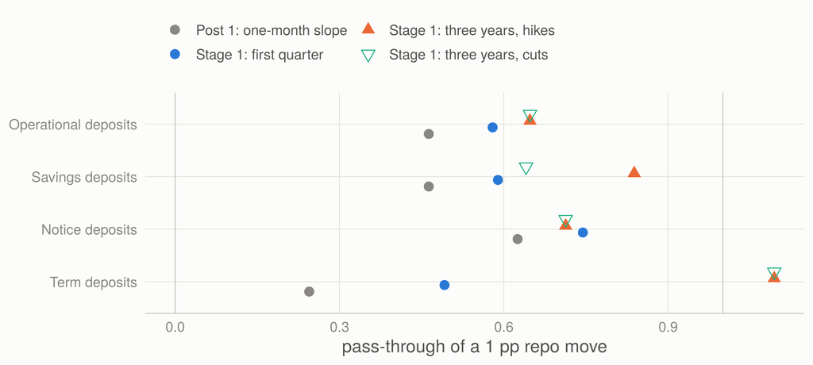

Pass-through of a permanent 1 pp repo move to each behavioural deposit line: Post 1’s one-month slopes against Stage 1’s response in the first quarter and after three years, for hikes and for cuts (model average). The engine uses Stage 1’s full dynamics.

```r
pt <- MC$pass_through
bmix <- line_pricing_map()[c("beh_operational", "beh_savings", "beh_notice", "beh_term")]
resp <- function(l, mv_, q) { w <- bmix[[l]]$cost
  sum(vapply(names(w), function(k) w[[k]] * pt$response[pt$target == k & pt$move == mv_ & pt$quarter == q], 0)) }
bb <- do.call(rbind, lapply(names(bmix), function(l) data.frame(
  line = l, post1 = ngfb_canonical()$deposit_beta[[l]], q1 = resp(l, "hike", 1),
  y3_hike = resp(l, "hike", CFG$horizon), y3_cut = resp(l, "cut", CFG$horizon))))
guard(bb$y3_hike[bb$line == "beh_savings"] > bb$y3_cut[bb$line == "beh_savings"] + 0.1,
      "savings: hikes pass through more than cuts")
guard(resp("beh_term", "hike", 4) > 0.95, "term money reprices fully within a year")
bl <- rbind(data.frame(line = bb$line, kind = "Post 1: one-month slope", beta = bb$post1),
            data.frame(line = bb$line, kind = "Stage 1: first quarter", beta = bb$q1),
            data.frame(line = bb$line, kind = "Stage 1: three years, hikes", beta = bb$y3_hike),
            data.frame(line = bb$line, kind = "Stage 1: three years, cuts", beta = bb$y3_cut))
bl$line <- factor(lab_line[bl$line], levels = rev(lab_line[names(bmix)]))
bl$kind <- factor(bl$kind, levels = unique(bl$kind))
ggplot(bl, aes(beta, line, colour = kind, shape = kind)) +
  geom_point(size = 3, position = position_dodge(width = 0.5)) +
  scale_colour_manual(values = c(ink[["muted"]], unname(pal$categorical[c(1, 2, 3)]))) +
  scale_shape_manual(values = c(16, 16, 17, 25)) +
  geom_vline(xintercept = c(0, 1), colour = ink[["axis"]], linewidth = 0.3) +
  labs(x = "pass-through of a 1 pp repo move", y = NULL) +
  guides(colour = guide_legend(nrow = 2), shape = guide_legend(nrow = 2))
```

**Table view**

| Line | Post 1 one-month | Stage 1, first quarter | Stage 1, three years (hikes) | Stage 1, three years (cuts) |
| --- | --- | --- | --- | --- |
| Operational deposits | 0.46 | 0.58 | 0.65 | 0.65 |
| Savings deposits | 0.46 | 0.59 | 0.84 | 0.64 |
| Notice deposits | 0.63 | 0.74 | 0.71 | 0.71 |
| Term deposits | 0.24 | 0.49 | 1.09 | 1.09 |

Post 1 reported one-month contemporaneous slopes on offered rates (book average about 0.44) and noted that “the long-run cumulative pass-through is higher”. Stage 1 works on BA120-implied *book* costs over a quarter. With the refined models, more of a rate move reaches deposit costs within the quarter than the earlier version allowed (0.58 for operational deposits and 0.59 for savings), and term money reprices fully within a year. Savings deposits are asymmetric: after three years 84% of a hike has passed through but only 64% of a cut, so cuts squeeze the sector’s savings margin by more than hikes widen it. Faster pass-through means a smaller deposit endowment, which is why NGFB’s hedge now more than offsets it (see Sensitivities).

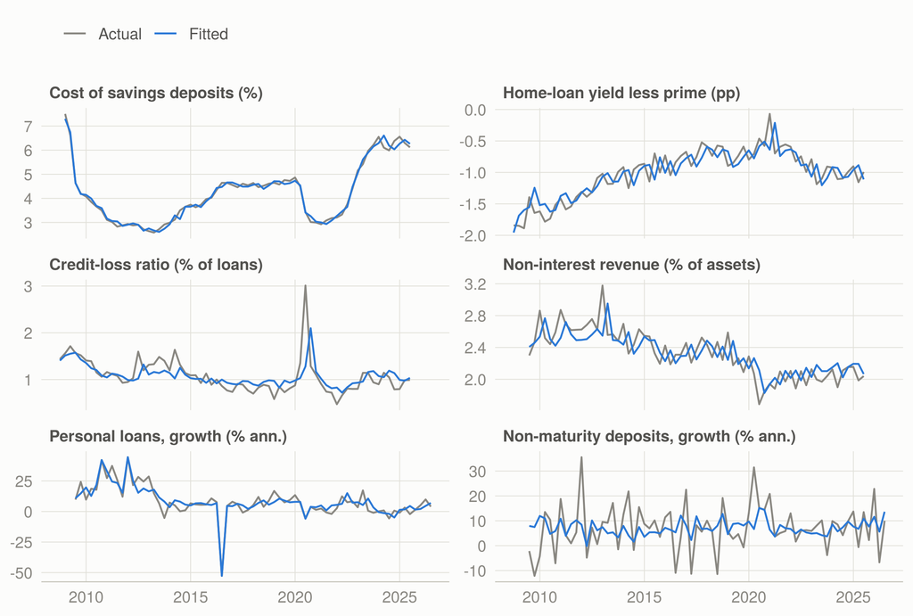

Selected Stage 1 models: actual against in-sample fitted values.

```r
show_t <- c(c_savings = "Cost of savings deposits (%)", s_homeloans = "Home-loan yield less prime (pp)",
            clr = "Credit-loss ratio (% of loans)", nir_assets = "Non-interest revenue (% of assets)",
            g_personal_other = "Personal loans, growth (% ann.)", g_nmd = "Non-maturity deposits, growth (% ann.)")
ff <- S1$fitted[S1$fitted$target %in% names(show_t), ]
ff$target <- factor(show_t[ff$target], levels = show_t)
fl <- rbind(data.frame(date = ff$date, target = ff$target, series = "Actual", value = ff$actual),
            data.frame(date = ff$date, target = ff$target, series = "Fitted", value = ff$fitted))
ggplot(fl, aes(date, value, colour = series)) +
  geom_line(linewidth = 0.55) +
  facet_wrap(~ target, ncol = 2, scales = "free_y") +
  scale_colour_manual(values = c(Actual = ink[["muted"]], Fitted = ent_col[["NGFB"]])) +
  labs(x = NULL, y = NULL)
```

# 6 Is ARDL the right tool?

The question deserves a direct answer, and it has three parts: why an ARDL is a sensible core for this problem, what alternatives and refinements could do better, and what happened when the most promising of them were tested on the same footing as the satellites themselves.

## 6.1 Why ARDL

- **Scenarios are conditional forecasts.** A scenario fixes the macro path; the models must say what the industry does *given* that path. Single-equation models conditioned on exogenous drivers do exactly that. A VAR would model the macro variables too, which a scenario overrides anyway.
- **Seventy quarters is a small sample.** An AR(1) term plus at most three drivers is about as much structure as 2008–2025 can support, and the sign restrictions stop the search from fitting noise with economically wrong coefficients.
- **The long run is interpretable.** An ARDL in levels is an error-correction model in disguise: $\beta/(1-\rho)$ is the steady-state effect of a driver, which is what a three-year projection converges to.
- **It is the supervisors’ workhorse.** The Federal Reserve models 20 of the 24 core components of pre-provision net revenue in its supervisory stress test with autoregressive models of ratios, and ECB research argues for averaging over many satellite equations rather than hand-picking one (Gross and Población, 2015), which is what the model averaging here does.

## 6.2 What could do better, and what was tested

Refinements tested in analysis/08_model_checks.R. Every test uses dynamic forecasts conditional on the realised macro path: pseudo-out-of-sample from expanding windows (horizons 1–4) and the eight-quarter back-test from 2019Q4 and 2021Q4.

| Refinement | Question | Verdict |
| --- | --- | --- |
| Out-of-sample significance (Clark–West) | Do the satellites beat an AR(1) by more than chance? | 16 of 22 at 10% (h = 4); pricing strongest, credit and fees/costs not significant |
| Level relationship (Pesaran–Shin–Smith bounds test) | Is a deposit cost tied to the repo rate in the long run? | confirmed for current accounts only; none for savings, call or fixed deposits |
| Impact and long-run pass-through estimated separately (ARDL(1,1) for deposit costs) | Does a richer short-run response forecast better? | adopted: better for all five deposit costs, on both tests |
| Asymmetric pass-through of hikes and cuts (partial sums) | Do hikes and cuts pass through differently? | significant in sample for 5 of 11 pricing targets; adopted for savings deposits and card yields |
| Convex credit losses (a kink in GDP growth below zero; log credit-loss ratio) | Do losses rise faster in a contraction than they fall in a boom? | strong in sample, better at 1–4 quarters, worse in the back-test: kept as a scenario sensitivity |
| Intercept correction at every origin; as a level shift or in the equation | Does the correction help, and in which form? | adopted as a level shift; helps fees and deposit costs, not credit losses |
| Forecast combination: BIC weights against the five best out of sample, and the single best | Is model averaging the right way to use the search? | BIC model averaging kept: it beat both alternatives in the back-test |

The rule for adopting a refinement was fixed before looking at the scenario results: it enters the core only if it improves **both** the pseudo-out-of-sample fit of the selected specification and the eight-quarter back-test of the model-averaged projection, the way the scenarios use it. Anything that passes one test and fails the other is reported as a sensitivity, not adopted.

### 6.2.1 Do the satellites beat the AR(1) by more than chance?

With some 4,000 specifications searched per target, a winning specification can beat the benchmark by luck. The Clark–West test asks whether the out-of-sample improvement is larger than the noise a bigger model adds when its extra coefficients are truly zero (a plain Diebold–Mariano test is biased against the larger model when the models are nested).

One-sided p-values; 40 expanding-window origins per target. With 22 tests at 10%, about 2 would pass by chance.

| Target | Family | Skill vs AR(1) | Clark-West p, h = 1 | Clark-West p, h = 4 |
| --- | --- | --- | --- | --- |
| Term-loan yield less JIBAR (pp) | pricing | 21% | 0.000 | 0.000 |
| Cost of current accounts (%) | pricing | 45% | 0.001 | 0.001 |
| Cost of NCDs (%) | pricing | 42% | 0.002 | 0.002 |
| Cost of fixed and notice deposits (%) | pricing | 40% | 0.015 | 0.006 |
| Home-loan yield less prime (pp) | pricing | 11% | 0.123 | 0.011 |
| Cost of savings deposits (%) | pricing | 66% | 0.007 | 0.013 |
| VAF yield less prime (pp) | pricing | 38% | 0.015 | 0.018 |
| Cost of call deposits (%) | pricing | 25% | 0.005 | 0.019 |
| Commercial-mortgage yield less prime (pp) | pricing | 11% | 0.008 | 0.038 |
| Card yield less prime (pp) | pricing | 5% | 0.053 | 0.110 |
| Overdraft yield less prime (pp) | pricing | 2% | 0.141 | 0.208 |
| Credit-loss ratio (% of average loans) | credit | 5% | 0.063 | 0.125 |
| Operating costs incl. indirect tax (% of average assets) | pnl | 4% | 0.103 | 0.114 |
| Non-interest revenue (% of average assets) | pnl | 5% | 0.014 | 0.161 |
| Personal and other retail loans | volume | 11% | 0.019 | 0.001 |
| Term deposits (over 1 month) | volume | 5% | 0.027 | 0.018 |
| Vehicle and asset finance | volume | 9% | 0.022 | 0.019 |
| Commercial mortgages | volume | 2% | 0.072 | 0.074 |
| Non-maturity deposits (operational, savings, notice) | volume | 1% | 0.179 | 0.079 |
| Credit cards | volume | 10% | 0.082 | 0.080 |
| Corporate loans and overdrafts | volume | 6% | 0.049 | 0.086 |
| Residential mortgages | volume | 0% | 0.064 | 0.138 |

16 of 22 satellites pass at 10% (12 at 5%), far more than the 2 chance alone would deliver. The split by family is the honest part: every pricing model except cards and overdrafts carries significant information, the volume models mostly marginal information, and the credit-loss and fee and cost models do **not** beat the AR(1) significantly at the four-quarter horizon. For credit losses that is a statement about 2015–2025, which held one deep recession (2020) for the test to score; it is also why the credit model’s economics (losses rise when growth falls) rest on the full sample and on the model average rather than on its forecasting record.

### 6.2.2 Is a deposit cost tied to the repo rate in the long run?

A levels regression of one persistent series on another can be spurious. The Pesaran–Shin–Smith bounds test asks whether a level relationship exists without having to know whether the series are stationary; its critical values are simulated here for the actual sample size.

Bounds test, unrestricted intercept and no trend, one lag of the differences, impulse dummies as controls. Critical values from 4,000 simulations at the sample size. ‘Asymmetric’: the repo rate split into cumulative hikes and cuts.

| Deposit cost | F | 5% bounds, I(0) / I(1) | Decision | F, asymmetric | 5% bounds, asymmetric | Decision, asymmetric |
| --- | --- | --- | --- | --- | --- | --- |
| Current accounts | 8.06 | 5.03 / 6.03 | level relationship | 7.61 | 4.00 / 5.15 | level relationship |
| Savings | 0.18 | 5.03 / 6.03 | no level relationship | 0.96 | 4.00 / 5.15 | no level relationship |
| Call | 1.84 | 5.03 / 6.03 | no level relationship | 3.26 | 4.00 / 5.15 | no level relationship |
| Fixed and notice | 1.36 | 5.03 / 6.03 | no level relationship | 2.19 | 4.00 / 5.15 | no level relationship |
| NCDs | 5.69 | 5.03 / 6.03 | inconclusive | 4.23 | 4.00 / 5.15 | inconclusive |

The test confirms a long-run anchor for current accounts and cannot find one for savings, call and fixed deposits, with or without asymmetry. Part of that is low power in 67 quarters; part is real: the composition of each BA120 category drifts (digital banks’ savings products, the mix of corporate and retail call money), so the level relationship moves. The practical consequence is that these deposit costs are best modelled through their short-run response to rate *changes*, which is well identified, with a long run that is pinned down weakly, and that is what the next refinement does.

### 6.2.3 Impact and long-run pass-through, and asymmetry

The original search allowed the repo level *or* its change in a deposit-cost equation, never both. That forces the impact of a rate move and its long-run pass-through into one geometric profile. Letting both enter (an ARDL(1,1)) separates them:

Deposit-cost models under three registries. OOS RMSE: the selected specification, horizons 1–4. Back-test RMSE: the model-averaged projection over eight quarters, mean of the 2019Q4 and 2021Q4 origins (percentage points). Symmetry test: HAC Wald test of equal pass-through of hikes and cuts, nested in the ARDL(1,1).

| Deposit cost | OOS RMSE: original | ARDL(1,1) | ARDL(1,1), asymmetric | Back-test RMSE: original | ARDL(1,1) | ARDL(1,1), asymmetric | Symmetry rejected (p) | Adopted |
| --- | --- | --- | --- | --- | --- | --- | --- | --- |
| Current accounts | 0.394 | 0.315 | 0.237 | 0.424 | 0.423 | 0.446 | 0.000 | ARDL(1,1) |
| Savings | 0.636 | 0.261 | 0.240 | 1.459 | 1.278 | 0.222 | 0.052 | ARDL(1,1), asymmetric |
| Call | 1.072 | 0.878 | 0.904 | 1.333 | 0.864 | 0.965 | 0.119 | ARDL(1,1) |
| Fixed and notice | 0.702 | 0.686 | 0.767 | 1.024 | 0.854 | 1.276 | 0.030 | ARDL(1,1) |
| NCDs | 0.616 | 0.592 | 0.630 | 0.841 | 0.723 | 0.750 | 0.501 | ARDL(1,1) |

### 6.2.4 Are credit losses convex in a contraction?

Credit-loss ratio: the two leading members of the model average, linear, with a kink in GDP growth below zero, and in logs. Log-model slopes are semi-elasticities.

| Base specification | Variant | GDP slope | Kink slope (growth below 0) | t, kink | OOS RMSE | Back-test RMSE, 2019Q4 | Back-test RMSE, 2021Q4 |
| --- | --- | --- | --- | --- | --- | --- | --- |
| gdp_yy[L0] | linear | -0.043 | — | — | 0.480 | 0.784 | 0.108 |
| gdp_yy[L0] | kink | -0.002 | -0.082 | -3.8 | 0.437 | 0.835 | 0.238 |
| gdp_yy[L0] | log | -0.022 | — | — | 0.480 | 0.762 | 0.225 |
| gdp_yy[L0] | log_kink | -0.007 | -0.030 | -2.3 | 0.442 | 0.935 | 0.268 |
| gdp_yy[L0] + repo[L1] | linear | -0.041 | — | — | 0.521 | 0.871 | 0.153 |
| gdp_yy[L0] + repo[L1] | kink | 0.011 | -0.101 | -4.3 | 0.457 | 0.725 | 0.179 |
| gdp_yy[L0] + repo[L1] | log | -0.021 | — | — | 0.498 | 0.805 | 0.205 |
| gdp_yy[L0] + repo[L1] | log_kink | 0.001 | -0.043 | -3.0 | 0.437 | 0.722 | 0.242 |

The data say yes, strongly in sample: with a kink, growth above zero barely moves the loss ratio (slope -0.002 against -0.043 in the linear model) while each point of contraction adds 0.082 pp on impact ($t$ = -3.8). The kinked model also forecasts better at one to four quarters (RMSE 0.403 against 0.454 for the full search), but not over the eight-quarter back-test, where it has only 2009 to learn the kink from before 2020. It is therefore a sensitivity rather than the core, and an important one, shown in Scenarios: it removes about 43% of the upside’s credit benefit and leaves the downside almost unchanged.

### 6.2.5 The intercept correction

The correction (mean residual of the last four unflagged quarters) evaluated at every pseudo-out-of-sample origin. Ratios below one favour the correction. AR: the autoregressive coefficient of the selected model.

| Target | AR | RMSE, no correction | RMSE ratio, level shift | RMSE ratio, in the equation | Diebold-Mariano p (level) |
| --- | --- | --- | --- | --- | --- |
| Credit-loss ratio (% of average loans) | 0.52 | 0.454 | 1.08 | 1.24 | 0.316 |
| Non-interest revenue (% of average assets) | 0.73 | 0.265 | 0.75 | 0.70 | 0.000 |
| Operating costs incl. indirect tax (% of average assets) | 0.75 | 0.145 | 1.00 | 1.07 | 0.958 |
| Cost of call deposits (%) | 0.84 | 0.878 | 0.96 | 0.95 | 0.031 |
| Cost of current accounts (%) | 0.81 | 0.315 | 0.84 | 0.74 | 0.000 |
| Cost of fixed and notice deposits (%) | 0.57 | 0.686 | 0.77 | 0.77 | 0.001 |
| Cost of NCDs (%) | 0.54 | 0.592 | 0.98 | 1.03 | 0.566 |
| Cost of savings deposits (%) | 0.94 | 0.240 | 1.03 | 1.10 | 0.052 |
| Card yield less prime (pp) | 0.74 | 0.766 | 0.97 | 0.99 | 0.461 |
| Commercial-mortgage yield less prime (pp) | 0.23 | 0.341 | 0.98 | 0.98 | 0.581 |
| Home-loan yield less prime (pp) | 0.84 | 0.203 | 0.99 | 1.07 | 0.844 |
| Overdraft yield less prime (pp) | 0.27 | 0.676 | 0.80 | 0.80 | 0.002 |
| Term-loan yield less JIBAR (pp) | 0.89 | 0.654 | 0.88 | 0.90 | 0.038 |
| VAF yield less prime (pp) | 0.86 | 0.229 | 1.02 | 1.09 | 0.130 |

The previous version added the recent residual to the equation’s intercept, where it compounds through the autoregressive term to roughly $\text{ic}/(1-\rho)$. That is the right correction for a shift in a series’ equilibrium mean, but with the ARDL(1,1) deposit models, whose $\rho$ is close to one, it turns a few basis points of recent residual into a drift of a percentage point or more. Applied instead as a level shift of the projected path, the correction helps non-interest revenue (RMSE 25% lower), current, call and fixed deposits and the overdraft and term-loan spreads, and is neutral or slightly negative elsewhere. It does not help the credit-loss ratio, where it lowers the projected loss ratio by about 0.23 pp of loans and is worth 144 bps of NGFB’s baseline ROE: the single largest modelling assumption behind the *level* of ROE in this report (the two-origin back-test favours it; the test across 40 origins slightly disfavours it, not significantly).

### 6.2.6 Model averaging, selection or combination?

Median back-test skill against no change, with the whole search re-run at each origin.

| Family | BIC model average (used) | Five best out of sample, equal weights | Single best out of sample |
| --- | --- | --- | --- |
| credit | 37% | 36% | 37% |
| pnl | -8% | -113% | -98% |
| pricing | 56% | 51% | 40% |
| volume | 5% | -13% | -35% |

Selecting the specification with the best pseudo-out-of-sample record is the natural instinct, and it is wrong here: on genuinely new data the single best specification does worst (median skill 2%), an equal-weighted average of the five best does little better (5%), and the BIC-weighted model average does best (14%). Ranking by out-of-sample RMSE over a few dozen origins overfits the ranking itself (a winner’s curse), while BIC weights spread the bet across specifications that fit the whole sample.

## 6.3 What would improve accuracy most

The tests point to the data rather than the model class. In order of likely value:

1. **A bank’s own data.** NGFB inherits the sector’s pricing and loss rates. A real bank would replace the Stage 1 pricing with its own product pricing and the relative loss multipliers with its own loss history, which removes the largest source of error at bank level.
2. **Monthly data for pricing – tested, and it does not.** BA120 is monthly (210 months against 70 quarters), so estimating the pricing models monthly looked like the obvious way to sharpen the short-run dynamics the tests above found to matter. The next chapter does it, and the monthly models forecast the same quarterly outcomes less accurately: the extra observations bring more noise than information about repricing that happens over quarters.
3. **Loss data by product.** BA200 publishes no losses by product, so credit enters the engine as one sector ratio with assumed relative multipliers; impairment data by asset class would allow a product-level credit model, and a convex one with more than two recessions to learn from.
4. **Longer samples through structural breaks.** IFRS 9 (2018) changed how losses are recognised; a time-varying intercept (a state-space local level) is the principled version of the intercept correction once there is enough post-2018 data to estimate it.

Machine-learning alternatives are a poor fit for this problem: with 70 observations they overfit, and tree-based methods cannot extrapolate beyond the historical range, which a downside scenario routinely requires.

# 7 Monthly frequency: would the models fit better?

South African banking data are richer at monthly frequency than the quarterly models use: BA900 is a monthly return for every bank, BA120 (the sector’s income statement) is monthly, and so are the policy rate, bond yields, inflation, the rand, equity prices, the SARB’s coincident indicator and its credit statistics. Real GDP, the unemployment rate and house prices are not. This chapter builds the monthly version of Stage 1, tests it against the quarterly one on the same outcomes, asks whether ARDL is still the right tool at that frequency, and uses the satellites to show what rates and growth do to each line of the balance sheet.

**Data used here**

Monthly volumes are the BA900 returns of every month from January 2008 to June 2026 (222 months), for the same banks as the quarterly panel, so the three monthly growth rates of a quarter average exactly to the quarterly growth rate the production models use. Monthly pricing, credit-loss, fee and cost ratios divide the monthly BA120 income statement by the monthly BA100 balance sheet. The quarterly ratios divide a quarter’s flow by the average of its two quarter-end balances, the monthly ones divide each month’s flow by that month’s average balance, and the two differ when balances move within the quarter: by 0.02 pp on average for savings deposits (at most 0.09 pp), and by up to 0.5 pp for current accounts and NCDs in 2008-09. The comparison below scores every model on the production definition, and checks the monthly models on their own.

## 7.1 Quarterly series to monthly: the Kalman filter

A monthly model needs monthly GDP, and the monthly path has to satisfy two conditions: its three months must add up to the published quarter, and its shape within the quarter should come from monthly data, not from a smooth curve drawn through the quarters. That is temporal disaggregation (Chow and Lin, 1971; Fernández, 1981; Litterman, 1983), and its natural home is the state-space form (Harvey and Pierse, 1984; Proietti, 2006):

$$y_t = x_t'\beta + u_t, \qquad u_t = \phi\, u_{t-1} + \varepsilon_t, \qquad Y_q = \sum_{t \in q} c\, y_t ,$$

where $y_t$ is the unobserved monthly series, $x_t$ the monthly indicators, $u_t$ the part the indicators miss, and $Y_q$ the published quarter. A “cumulator” state adds up the months of each quarter and is observed only in its last month; the two months in between are missing observations, which the Kalman filter handles by skipping the update. $\beta$ is estimated by generalised least squares on the quarters, $\phi$ by maximising the profile likelihood, and the monthly path is the Kalman smoother’s estimate, with a standard error for every month. The same path has a closed form (the GLS best linear unbiased predictor); the package computes both and its tests check that they agree to machine precision. Months after the last published quarter, for which the indicators already exist, are extrapolated: a nowcast.

Which indicators? The test is out of sample: for each quarter from 2012, the model is estimated on the quarters before it and the indicators up to its end, and the three months it extrapolates are summed into a nowcast of the quarter.

Out-of-sample nowcasts of quarterly real GDP growth (annualised, percentage points), 2012Q1-2026Q1. Indicators: the SARB coincident business-cycle indicator, manufacturing production and retail sales at constant prices. The AR(1) uses quarterly GDP only.

| Indicators | Model | Quarters | RMSE, all | RMSE, excluding 2020 | AR(1), all | AR(1), excluding 2020 |
| --- | --- | --- | --- | --- | --- | --- |
| None (smooth path) | Litterman | 57 | 19.36 | 3.37 | 20.15 | 2.72 |
| Coincident indicator | Chow-Lin | 57 | 5.97 | 2.56 | 20.15 | 2.72 |
| Manufacturing + retail | Chow-Lin | 57 | 3.65 | 2.24 | 20.15 | 2.72 |
| Coincident + manufacturing + retail | Chow-Lin | 57 | 4.22 | 2.13 | 20.15 | 2.72 |
| Coincident + manufacturing + retail | Litterman | 57 | 5.34 | 2.19 | 20.15 | 2.72 |

The coincident indicator with manufacturing and retail sales, in a Chow-Lin model, nowcasts GDP growth with an error of 2.13 pp outside 2020 against 2.72 pp for an AR(1) that sees no monthly data, so its monthly path carries real information about the quarter; a path with no indicators (3.37 pp) does not. The estimated $\phi$ is 0.995, the top of the range searched: the gap between GDP and the indicators behaves almost like a random walk (Fernández’s case), which is why the filter re-anchors to every published quarter. Unemployment (published quarterly only since the Quarterly Labour Force Survey began in 2008) and house prices have no monthly indicator here, so they get the smooth path whose quarterly averages match (a Litterman model without regressors).

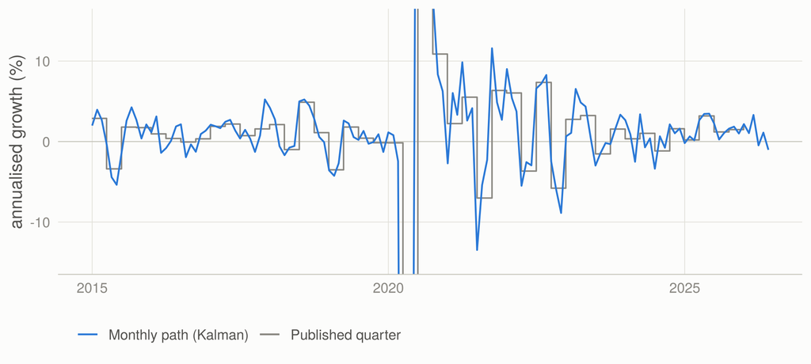

Real GDP growth: the published quarters (annualised quarter on quarter) and the monthly path from the Kalman filter (annualised three-month growth), 2015-2026; the 2020 collapse and rebound run off the scale. The last three months are a nowcast from the indicators.

```r
gm <- MM$disaggregation$gdp_monthly
gm$g3 <- 400 * (log(gm$gdp_m) - log(c(rep(NA, 3), utils::head(gm$gdp_m, -3))))
gq <- P$macro[, c("date", "gdp_qq")]
gq <- gq[gq$date >= as.Date("2015-01-01") & is.finite(gq$gdp_qq), ]
gm <- gm[gm$date >= as.Date("2015-01-01"), ]
ggplot() +
  geom_hline(yintercept = 0, colour = ink[["axis"]], linewidth = 0.3) +
  geom_step(data = transform(gq, date = date - 91), aes(date, gdp_qq, colour = "Published quarter"), linewidth = 0.5,
            direction = "hv") +
  geom_line(data = gm, aes(date, g3, colour = "Monthly path (Kalman)"), linewidth = 0.6) +
  scale_colour_manual(values = c(`Published quarter` = ink[["muted"]], `Monthly path (Kalman)` = ent_col[["NGFB"]]), name = NULL) +
  coord_cartesian(ylim = c(-15, 15)) +
  labs(x = NULL, y = "annualised growth (%)") +
  theme(legend.position = "bottom")
```

## 7.2 Monthly against quarterly

The monthly satellites are built exactly like the quarterly ones – the same registry of targets, candidate drivers, economic signs and driver groups, the same $|t| \ge 1$ and $|\rho| < 0.98$ screens, model averaging with BIC weights – with three changes the frequency forces: lags of 0, 1, 2, 3, 6, 9 and 12 months; month-of-year dummies (and the COVID quarters month by month); and the dynamic out-of-sample selection run twelve months ahead from quarter-end origins. Monthly interest is annualised with the month’s day count, since interest accrues by the day (a first pass annualised it by twelve, which reads every February as a fall in rates).

The comparison is the one that matters: both models forecast the *same quarterly outcomes* from the *same origins*, re-estimated on data up to each origin and simulated forward along the realised macro path, exactly as in a scenario. Monthly forecasts map into quarters exactly: three months of annualised growth average to the quarter’s growth, and day-weighted monthly interest rates sum to the quarterly rate.

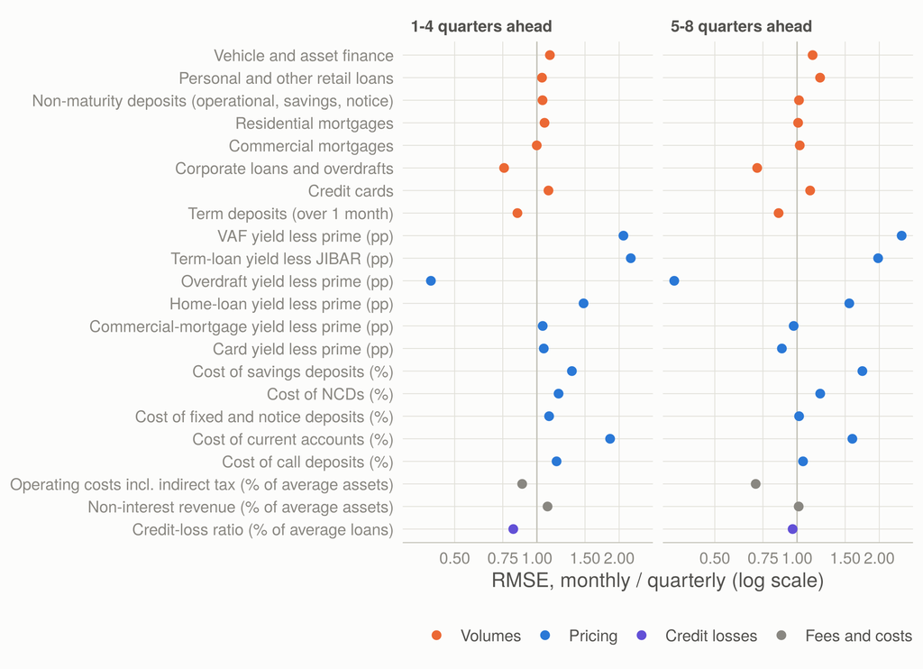

Forecast error of the monthly ARDL relative to the quarterly ARDL (RMSE ratio; below one, monthly is better), by target and horizon. Same quarterly outcomes, same origins.

```r
rr <- rw
rr$lab <- vapply(rr$target, function(t) S1$sats[[t]]$label %||% t, "")
rr$lab <- factor(rr$lab, levels = unique(rr$lab[order(rr$family, rr$target)]))
rr$block <- ifelse(rr$block == "h1_4", "1-4 quarters ahead", "5-8 quarters ahead")
rr$family <- fam_lab[rr$family]
ggplot(rr, aes(r_m_ardl, lab, colour = family)) +
  geom_vline(xintercept = 1, colour = ink[["axis"]], linewidth = 0.4) +
  geom_point(size = 2.2) +
  facet_wrap(~ block) +
  scale_x_log10(breaks = c(0.5, 0.75, 1, 1.5, 2, 3)) +
  scale_colour_manual(values = c(Volumes = ent_col[["Big Four"]], Pricing = ent_col[["NGFB"]],
                                 `Credit losses` = pal$categorical[[7]], `Fees and costs` = ink[["muted"]]),
                      breaks = unname(fam_lab), name = NULL) +
  labs(x = "RMSE, monthly / quarterly (log scale)", y = NULL) +
  theme(legend.position = "bottom")
```

**Table view: monthly against quarterly, with Diebold-Mariano tests (1-4 quarters)**

| Target | Quarterly RMSE, 1-4 q | Monthly / quarterly, 1-4 q | Monthly / quarterly, 5-8 q | Diebold-Mariano (positive favours monthly) | p-value |
| --- | --- | --- | --- | --- | --- |
| Cost of call deposits (%) | 0.913 | 1.18 | 1.05 | -0.89 | 0.376 |
| Cost of current accounts (%) | 0.349 | 1.85 | 1.59 | -3.90 | 0.000 |
| Cost of fixed and notice deposits (%) | 0.801 | 1.11 | 1.02 | -1.40 | 0.163 |
| Cost of NCDs (%) | 0.625 | 1.20 | 1.22 | -2.20 | 0.028 |
| Cost of savings deposits (%) | 0.271 | 1.34 | 1.73 | -1.16 | 0.244 |
| Credit-loss ratio (% of average loans) | 0.512 | 0.82 | 0.96 | 1.06 | 0.291 |
| Term deposits (over 1 month) | 13.744 | 0.85 | 0.86 | 4.99 | 0.000 |
| Credit cards | 7.297 | 1.10 | 1.12 | -0.66 | 0.510 |
| Corporate loans and overdrafts | 11.006 | 0.76 | 0.71 | 3.41 | 0.001 |
| Commercial mortgages | 3.710 | 1.00 | 1.02 | -0.03 | 0.976 |
| Residential mortgages | 2.267 | 1.07 | 1.01 | -0.86 | 0.388 |
| Non-maturity deposits (operational, savings, notice) | 9.243 | 1.05 | 1.02 | -0.84 | 0.400 |
| Personal and other retail loans | 5.799 | 1.04 | 1.21 | -0.28 | 0.776 |
| Vehicle and asset finance | 3.390 | 1.12 | 1.14 | -1.77 | 0.077 |
| Non-interest revenue (% of average assets) | 0.307 | 1.09 | 1.01 | -2.16 | 0.031 |
| Operating costs incl. indirect tax (% of average assets) | 0.158 | 0.88 | 0.71 | 0.45 | 0.650 |
| Card yield less prime (pp) | 0.785 | 1.06 | 0.88 | -0.83 | 0.406 |
| Commercial-mortgage yield less prime (pp) | 0.316 | 1.05 | 0.97 | -0.59 | 0.552 |
| Home-loan yield less prime (pp) | 0.258 | 1.48 | 1.55 | -2.19 | 0.029 |
| Overdraft yield less prime (pp) | 1.640 | 0.41 | 0.36 | 1.38 | 0.167 |
| Term-loan yield less JIBAR (pp) | 0.553 | 2.21 | 1.98 | -4.24 | 0.000 |
| VAF yield less prime (pp) | 0.229 | 2.07 | 2.41 | -3.29 | 0.001 |

**Monthly estimation does not fit better, with one informative exception.** For pricing, the family where monthly data were expected to help most, the median monthly model’s error is 1.20 times the quarterly model’s one to four quarters ahead and 1.22 times five to eight quarters ahead, and 1.17 times when the monthly models are scored on their own definition of the quarterly rate; for volumes the ratios are 1.05 and 1.02. Of the 22 Diebold-Mariano tests, 7 reject equal accuracy in favour of the quarterly model at 10% and 2 in favour of the monthly: corporate loans (error ratio 0.76) and term deposits (0.85), both at the 1% level. The credit-loss ratio (0.82 near term) and operating costs are also forecast better monthly, but not significantly.

The exception is the lumpiest business in the sector: corporate drawdowns and repayments, and institutional term placements, which partly reverse the next month (month-on-month growth has a first-order autocorrelation of -0.07 for corporate loans and -0.23 for term deposits). A quarterly model sees only that the quarter grew; a monthly model sees *when* in the quarter the lump arrived, and so whether its reversal is still to come. The gain is in the dynamics, not in the macro response: a monthly AR(1) with no macro drivers does as well (0.80 and 0.85). Across all volumes, the monthly AR(1) is the most accurate short-horizon forecaster of the eight (median ratio 0.89, against 0.96 for the quarterly AR(1)): the latest month carries momentum that a quarterly series reports late.

Why monthly data do not help more generally is a matter of signal and noise. The signal in these series is slow: a deposit book reprices over quarters, a credit cycle turns over years, and the policy rate moves only at the six MPC meetings a year, so monthly timing adds a few weeks of resolution at most. The noise is per observation: month-end balances, interest posted unevenly across months, provisions booked at quarter and year ends. Tripling the observations triples the noise draws without adding much independent information about slow dynamics, and in the monthly pricing models the autoregressive coefficient sits close to one (0.93 for savings deposits), where small estimation errors compound over a 24-month simulation. Quarterly aggregation is not a loss of information here; it is a filter.

**So the production models stay quarterly.** Monthly data still earn their place in two ways the evidence supports: the Kalman filter’s monthly GDP path is a genuine nowcast of the quarter in progress, and the latest month of BA900 and BA120 can update the jump-off book before the quarter closes – above all for corporate loans and term deposits, where a monthly view of the jump-off is significantly more accurate. Neither argues for monthly scenario models. What a three-year scenario needs from Stage 1 is the macro response, and on that the two frequencies broadly agree where it matters most for earnings, deposit pricing and unsecured lending (see the multipliers below).

## 7.3 Is ARDL still the right tool at monthly frequency?

The same race includes the two alternatives that make most sense when the lag dimension grows from five quarters to thirteen months: **polynomial distributed lags** (Almon), in which each driver enters through a quadratic lag profile over 0-12 months, so a rate change can be spread over a year with three parameters instead of thirteen, the sign restriction applying to the sum of the lag weights; and **Bayesian shrinkage**, the single-equation version of a Bayesian VAR with exogenous drivers, in which every candidate driver enters at every lag, coefficients are shrunk towards zero with a prior variance that falls with the lag (a Minnesota prior), and the tightness is set by the marginal likelihood – shrinkage instead of selection, and no signs.

Median forecast error by model class, relative to the quarterly sign-restricted ARDL average (below one is better). Same quarterly outcomes and origins for every model. PDL: polynomial distributed lags. No quarterly PDL specification for home loans survives the sign and t screens, so that median covers the other volume targets.

| Quarters ahead | Family | ARDL, quarterly | PDL, quarterly | Shrinkage, quarterly | AR(1), quarterly | ARDL, monthly | PDL, monthly | Shrinkage, monthly | AR(1), monthly |
| --- | --- | --- | --- | --- | --- | --- | --- | --- | --- |
| 1-4 | Volumes | 1.00 | 1.08 | 1.09 | 0.96 | 1.05 | 1.21 | 1.15 | 0.89 |
| 1-4 | Pricing | 1.00 | 1.15 | 1.12 | 1.34 | 1.20 | 1.46 | 1.63 | 1.60 |
| 1-4 | Credit losses | 1.00 | 1.15 | 1.05 | 0.98 | 0.82 | 0.91 | 1.00 | 0.82 |
| 1-4 | Fees and costs | 1.00 | 1.25 | 1.08 | 0.94 | 0.99 | 1.39 | 1.26 | 1.00 |
| 5-8 | Volumes | 1.00 | 1.06 | 1.18 | 0.95 | 1.02 | 1.14 | 1.26 | 0.89 |
| 5-8 | Pricing | 1.00 | 1.29 | 1.32 | 1.67 | 1.22 | 1.64 | 1.69 | 1.81 |
| 5-8 | Credit losses | 1.00 | 1.28 | 1.30 | 1.17 | 0.96 | 1.18 | 1.46 | 0.99 |
| 5-8 | Fees and costs | 1.00 | 1.05 | 1.04 | 0.86 | 0.86 | 1.16 | 1.10 | 0.84 |

**Yes.** Within each frequency the sign-restricted ARDL average is the most accurate macro model for pricing, ahead of both alternatives: polynomial lags impose a smooth lag profile that deposit repricing does not have (it is a jump at the MPC meeting followed by a tail), and shrinkage keeps every driver at every lag with small, often wrong-signed coefficients that add noise. For volumes no macro model beats a plain AR(1) one to eight quarters ahead (median ratio 0.96, and 0.89 for the monthly AR(1)): a loan book’s next quarter is mostly its last quarter. The macro information in volumes is in where a three-year scenario path ends, not in next quarter’s growth, which is why the satellites are chosen on multi-step accuracy and held to economic signs rather than fitted for the shortest horizon.

A VAR would not change this. In a scenario the macro path is set from outside, so the object needed is the distribution of each banking variable *conditional on* that path. A VAR’s conditional forecast (Waggoner and Zha, 1999) equals the ARDL’s when the macro block does not respond to the banking variables within the horizon; otherwise the VAR adds equations for macro variables that the scenario then overrides. The VAR’s real advantage, joint dynamics, matters for unconditional forecasting, not for scenario analysis.

Mixed-frequency regressions (MIDAS; Ghysels, Santa-Clara and Valkanov, 2004) solve a different problem: a target observed only quarterly, with drivers observed monthly. Here the targets are monthly too, so the monthly ARDL uses strictly more information than a MIDAS regression of the quarterly target on monthly drivers would, and the polynomial lags above are MIDAS’s weighting scheme applied at a single frequency.

## 7.4 How the lags are chosen and how the sign restrictions work

Each satellite is a model average over a disciplined search, not a single regression. For a target $y$ with candidate drivers $x_j$:

1. **Specifications.** Every subset of at most 3 drivers, at most one from each economic group (the repo level and its change never compete in one equation, unless the target’s registry allows both), each at **one** lag chosen from a grid – 0 to 4 quarters (0 to 12 months monthly): $y_t = c + \rho\, y_{t-1} + \sum_j \beta_j x_{j,t-\ell_j} + \varepsilon_t$. One lag per driver keeps the parameter count down; the AR term $\rho$ spreads the effect over time, so the response to a permanent change in $x_j$ is $0$ before $\ell_j$ and then $\beta_j(1 + \rho + \dots + \rho^{h-\ell_j})$, converging to the long-run multiplier $\beta_j / (1 - \rho)$.
2. **Sign restrictions.** A specification survives only if every driver’s short-run coefficient $\beta_j$ *and* long-run multiplier $\beta_j/(1-\rho)$ carry the sign economics requires (a higher repo rate cannot raise mortgage demand; higher unemployment cannot lower credit losses), where the registry fixes one, with $|t_{\text{HAC}}| \ge 1$, and $|\rho| < 0.98$. This is a restriction on the *model space*, not on a structural shock as in a sign-restricted VAR: it removes specifications whose estimated effects contradict the direction economics requires. Where theory is ambiguous the sign is left free: the policy rate for cards and corporate credit (a hike damps new borrowing but raises drawdowns on existing facilities as cash flow tightens) and for non-maturity deposits (higher rates draw money into savings and notice accounts and push it out to term deposits).
3. **Selection.** Survivors are ranked by dynamic pseudo-out-of-sample error – re-estimated at each origin and simulated four quarters ahead along the realised macro path – and the most parsimonious within 2% of the best is the selected specification.
4. **Averaging.** Projections average every surviving specification with BIC weights, an approximation to posterior model probabilities (Raftery, 1995), so lag uncertainty is carried into the scenario rather than resolved by fiat.

Home loans show how this works. Of the 4,090 candidate specifications, 26 survive the screens. The model average puts 67% of its weight on the four-quarter change in the repo rate, spread over lags of two quarters (24%), three (26%) and four (15%); the one-quarter change and the repo level carry the rest of the rate weight, also at two to four quarters, and specifications with house prices carry 28%. No single lag is imposed: a rate rise starts to slow home-loan growth after about two quarters and keeps slowing it for well over a year (at most 3% of the weight sits on lags of zero or one quarter). The selected specification, the four-quarter change at a two-quarter lag, is the most parsimonious within 2% of the best out-of-sample error; the scenarios use the average.

What the restrictions remove, quarterly production models. The last two columns re-run the search with every sign left free: the share of the model-average weight that lands on specifications with at least one economically wrong sign, and the out-of-sample error of that average relative to the restricted one (1-4 quarters); both are medians across the family’s targets.

| Family | Specifications | Fail a sign | Fail the t screen | Fail the ρ screen | Survive | Wrong-sign weight, unrestricted | RMSE, unrestricted / restricted |
| --- | --- | --- | --- | --- | --- | --- | --- |
| Credit losses | 4,890 | 90% | 9% | 0% | 20 | 100% | 0.93 |
| Fees and costs | 1,740 | 34% | 61% | 0% | 84 | 37% | 1.06 |
| Pricing | 4,260 | 28% | 56% | 2% | 589 | 0% | 1.00 |
| Volumes | 29,330 | 67% | 24% | 0% | 2,675 | 64% | 1.00 |

The restrictions matter exactly where the data are misleading. For pricing, the data and economics agree: without the restriction almost no weight lands on a wrong sign and accuracy is unchanged. For volumes they disagree. In home loans 95% of the 4,090 specifications fail a sign, and with the signs left free 100% of the model weight goes to specifications in which a higher repo rate *raises* mortgage growth. That is not a finding about mortgages; it is the SARB at work: it hikes into credit booms and cuts into slumps, so in the raw data rates and credit growth rise together. The unrestricted average learns that correlation and forecasts worse out of sample (2.92 against 2.17), and in a scenario it would turn a hike into a lending boom. The credit-loss ratio is the instructive exception: the free model forecasts slightly better near term (0.453 against 0.487), with all of its weight on wrong signs; the restricted model gives up a little short-horizon fit for the right causal direction, which is what a stress scenario needs.

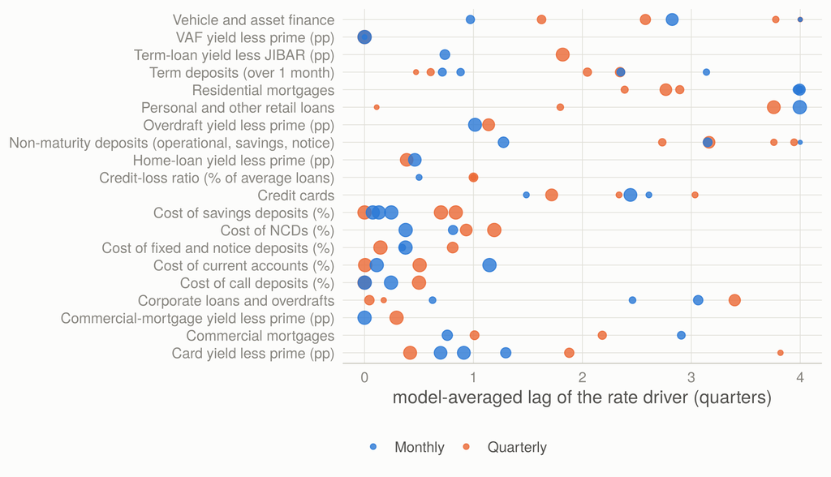

Where the rate effect sits: the model-averaged lag (in quarters) of the policy-rate drivers in each satellite, quarterly production models and monthly models (monthly volumes are shown only when they come from BA900). Larger points: more of the model weight on that driver.

```r
lp_rate <- DY$lag_profile[DY$lag_profile$driver %in% c("repo", "d_repo", "d4_repo", "real_repo", "repo_pos",
                                                         "repo_neg", "d_repo_pos", "d_repo_neg"), ]
if (MM$vol_source == "KBP") lp_rate <- lp_rate[!(lp_rate$freq == "month" & grepl("^g_", lp_rate$target)), ]
lp_rate$lab <- vapply(lp_rate$target, function(t) S1$sats[[t]]$label %||% t, "")
lp_rate$freq <- ifelse(lp_rate$freq == "quarter", "Quarterly", "Monthly")
ggplot(lp_rate, aes(lag, lab, colour = freq)) +
  geom_point(aes(size = w), alpha = 0.8) +
  scale_size_continuous(range = c(1, 4), guide = "none") +
  scale_colour_manual(values = c(Quarterly = ent_col[["Big Four"]], Monthly = ent_col[["NGFB"]]), name = NULL) +
  labs(x = "model-averaged lag of the rate driver (quarters)", y = NULL) +
  theme(legend.position = "bottom")
```

Deposit costs carry their rate effect within about a quarter at both frequencies. Retail loan books are the opposite: the monthly models put almost all of their rate weight at the longest lag the grid allows, twelve months, for home loans and personal loans (both at 4.0 quarters), and the quarterly models, whose grid reaches the same year, at 2.8 and 3.6 quarters. Both frequencies say a rate change takes the best part of a year to reach a retail loan book; at the boundary, the monthly grid cannot say whether it takes longer.

## 7.5 Dynamic multipliers: what a rate move does to each line

A dynamic multiplier is the path of a line after a shock, all else equal. Because the satellites average several specifications whose rate drivers include the level, its one- and four-period changes, the real rate and the partial sums of hikes and cuts, the multipliers are computed by simulation: each model is projected along a flat macro path and along the same path with the shock, every derived driver recomputed (a repo shock moves prime, JIBAR, the real rate, the changes and the partial sums together), and the difference is the multiplier. Bands redraw the coefficients of the averaged specifications from their HAC covariance (5th to 95th percentile).

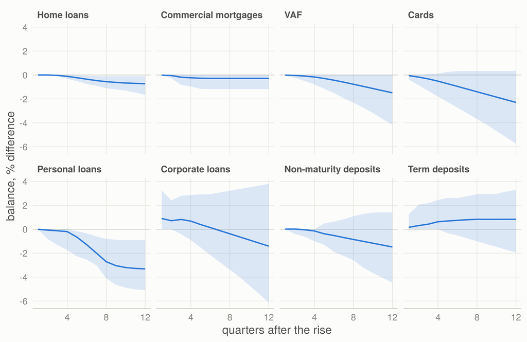

A permanent 100 bps rise in the repo rate: the level of sector balances, percent difference from no change, quarterly production models with a 90% parameter band (all else equal: the macro path is otherwise unchanged).

```r
vt <- c("g_mortgages_res", "g_mortgages_com", "g_vaf", "g_cards", "g_personal_other", "g_corp_all", "g_nmd", "g_beh_term")
mv1 <- mu[mu$set == "production" & mu$shock == "repo_up" & mu$target %in% vt, ]
mv1$lab <- factor(plab[sub("^g_", "", mv1$target)], levels = plab)
ggplot(mv1, aes(quarters, effect)) +
  geom_hline(yintercept = 0, colour = ink[["axis"]], linewidth = 0.3) +
  geom_ribbon(aes(ymin = lo, ymax = hi), fill = ent_col[["NGFB"]], alpha = 0.15) +
  geom_line(colour = ent_col[["NGFB"]], linewidth = 0.7) +
  facet_wrap(~ lab, ncol = 4) +
  scale_x_continuous(breaks = c(0, 4, 8, 12)) +
  labs(x = "quarters after the rise", y = "balance, % difference")
```

**Table view: balances after a permanent 100 bps rise in the repo rate (% difference)**

| Line | After 1 year | After 2 years | After 3 years | 90% band, 3 years |
| --- | --- | --- | --- | --- |
| Home loans | -0.12 | -0.56 | -0.73 | -1.67 to -0.11 |
| Commercial mortgages | -0.23 | -0.28 | -0.28 | -1.18 to +0.00 |
| VAF | -0.17 | -0.77 | -1.49 | -4.14 to +0.00 |
| Cards | -0.52 | -1.40 | -2.29 | -5.74 to +0.35 |
| Personal loans | -0.20 | -2.71 | -3.31 | -5.09 to -0.90 |
| Corporate loans | +0.68 | -0.38 | -1.42 | -6.13 to +3.79 |
| Non-maturity deposits | -0.15 | -0.86 | -1.48 | -4.46 to +1.40 |
| Term deposits | +0.62 | +0.83 | +0.83 | -1.95 to +3.28 |

Loan books respond slowly and unsecured lending most: three years after a permanent 100 bps rise, personal loans are 3.3% smaller than they would have been, cards 2.3%, vehicle and asset finance 1.5% and home loans 0.7%, with little happening in the first year. Term deposits *grow* (+0.8%): savers move into fixed deposits when rates are high. These are partial effects with the rest of the macro path held fixed; in a scenario a hike also slows GDP and raises unemployment, which add their own effects through the other drivers.

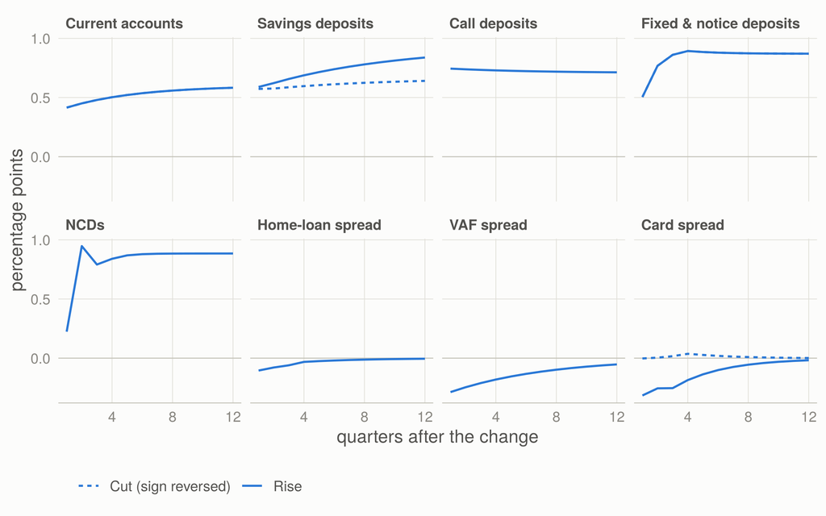

A permanent 100 bps change in the repo rate: deposit costs and loan spreads over their reference rates (percentage points), quarterly production models. Solid: a rise; dashed: a cut (shown with its sign reversed, so that a symmetric response would overlap).

```r
pt <- c("c_current", "c_savings", "c_call", "c_fixed_notice", "c_ncd", "s_homeloans", "s_vaf", "s_cards")
mp <- mu[mu$set == "production" & mu$target %in% pt & mu$shock %in% c("repo_up", "repo_down"), ]
mp$effect[mp$shock == "repo_down"] <- -mp$effect[mp$shock == "repo_down"]
mp$lab <- factor(tlab[mp$target], levels = tlab[pt])
mp$shock <- ifelse(mp$shock == "repo_up", "Rise", "Cut (sign reversed)")
ggplot(mp, aes(quarters, effect, linetype = shock)) +
  geom_hline(yintercept = 0, colour = ink[["axis"]], linewidth = 0.3) +
  geom_line(colour = ent_col[["NGFB"]], linewidth = 0.7) +
  facet_wrap(~ lab, ncol = 4) +
  scale_x_continuous(breaks = c(0, 4, 8, 12)) +
  scale_linetype_manual(values = c(Rise = "solid", `Cut (sign reversed)` = "22"), name = NULL) +
  labs(x = "quarters after the change", y = "percentage points") +
  theme(legend.position = "bottom")
```

Deposit costs reprice at very different speeds. Call deposits move almost at once (0.74 pp in the first quarter after a 100 bps rise); savings and current accounts move part of the way (0.59 and 0.41); NCDs only as they roll over (0.22 at first, 0.84 after a year). After three years fixed and notice deposits and NCDs have passed through almost fully (0.87 and 0.88) and current accounts least (0.58). Savings deposits show the asymmetry: a 100 bps rise adds 0.84 pp to their cost after three years, a 100 bps cut takes off only 0.64 pp, which is what squeezes the savings margin in an easing cycle. Loan yields are set off prime, which moves one for one with the repo rate, so their spreads dip on impact (the book reprices with a lag) and close within a year or two: vehicle and asset finance by 0.29 pp at first and cards by 0.32 pp.

### 7.5.1 The first months, seen monthly

The quarterly models report the first quarter as one number. The monthly models, estimated on the same lines with the same signs, show what happens inside it.

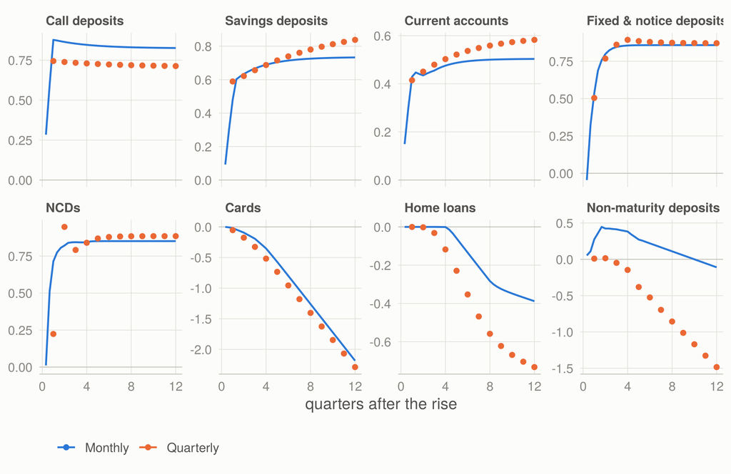

A permanent 100 bps rise in the repo rate, monthly models (line, month by month) against the quarterly production models (points, one per quarter): deposit costs in percentage points, balances in % difference. The first three years.

```r
ft <- c("c_call", "c_savings", "c_current", "c_fixed_notice", "c_ncd", "g_cards", "g_mortgages_res", "g_nmd")
mf <- mu[mu$shock == "repo_up" & mu$target %in% ft & mu$set %in% c("production", "monthly"), ]
mf$lab <- factor(tlab[mf$target], levels = tlab[ft])
mf$set <- ifelse(mf$set == "production", "Quarterly", "Monthly")
ggplot(mf, aes(quarters, effect, colour = set)) +
  geom_hline(yintercept = 0, colour = ink[["axis"]], linewidth = 0.3) +
  geom_line(data = mf[mf$set == "Monthly", ], linewidth = 0.7) +
  geom_point(data = mf[mf$set == "Quarterly", ], size = 1.6) +
  facet_wrap(~ lab, ncol = 4, scales = "free_y") +
  scale_x_continuous(breaks = c(0, 4, 8, 12)) +
  scale_colour_manual(values = c(Monthly = ent_col[["NGFB"]], Quarterly = ent_col[["Big Four"]]), name = NULL) +
  labs(x = "quarters after the rise", y = NULL) +
  theme(legend.position = "bottom")
```

**Table view: monthly against quarterly multipliers (deposit costs in pp, balances in %)**

| Line | Month 1 | Month 2 | Quarter 1, monthly | Quarter 1, quarterly | Year 3, monthly | Year 3, quarterly |
| --- | --- | --- | --- | --- | --- | --- |
| Call deposits | +0.28 | +0.59 | +0.88 | +0.74 | +0.83 | +0.71 |
| Savings deposits | +0.09 | +0.30 | +0.48 | +0.59 | +0.73 | +0.84 |
| Current accounts | +0.15 | +0.30 | +0.43 | +0.41 | +0.50 | +0.58 |
| Fixed & notice deposits | -0.05 | +0.32 | +0.54 | +0.50 | +0.86 | +0.87 |
| NCDs | +0.01 | +0.51 | +0.71 | +0.22 | +0.85 | +0.88 |
| Cards | +0.00 | -0.01 | -0.02 | -0.05 | -2.19 | -2.29 |
| Home loans | +0.00 | +0.00 | +0.00 | 0.00 | -0.39 | -0.73 |
| Non-maturity deposits | +0.05 | +0.11 | +0.27 | +0.01 | -0.11 | -1.48 |

Call deposits have repriced 59 bps two months after a 100 bps rise. NCDs barely move in the first month (+1 bps) and then reprice 51 bps in the second as certificates roll over; fixed and notice deposits follow the same pattern. Savings and current accounts have each moved about 30 bps after two months. After three years the monthly and quarterly models are within 0.11 pp of each other on every deposit line, so for NII over a scenario the frequency hardly matters; for the first quarter of a rate cycle – the quarter an ALCO is usually asked about – the monthly profile is the better guide. For balances the two frequencies agree on unsecured lending (cards -2.2% monthly against -2.3% quarterly after three years) and on the timing of home loans, which slow only from the second year (the monthly response is smaller, -0.4% against -0.7%). They disagree on non-maturity deposits, where the monthly model finds a small, temporary inflow (+0.4% after a year) and the quarterly model a gradual outflow (-1.5% after three years), both with bands that span zero: volume elasticities remain the least well identified part of Stage 1.

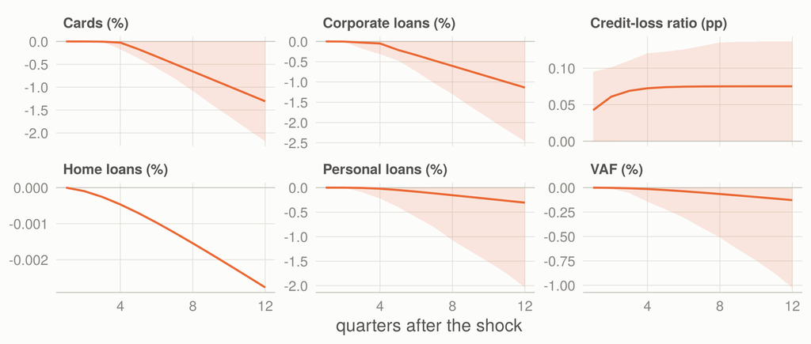

GDP growth one percentage point lower, permanently: the sector’s credit-loss ratio (percentage points) and loan balances (% difference), quarterly production models.

```r
gt <- c("clr", "g_mortgages_res", "g_vaf", "g_cards", "g_personal_other", "g_corp_all")
mg2 <- mu[mu$set == "production" & mu$shock == "gdp_down" & mu$target %in% gt, ]
mg2$lab <- ifelse(mg2$target == "clr", "Credit-loss ratio (pp)", paste0(plab[sub("^g_", "", mg2$target)], " (%)"))
ggplot(mg2, aes(quarters, effect)) +
  geom_hline(yintercept = 0, colour = ink[["axis"]], linewidth = 0.3) +
  geom_ribbon(aes(ymin = lo, ymax = hi), fill = sc_col[["downside"]], alpha = 0.15) +
  geom_line(colour = sc_col[["downside"]], linewidth = 0.7) +
  facet_wrap(~ lab, ncol = 3, scales = "free_y") +
  scale_x_continuous(breaks = c(0, 4, 8, 12)) +
  labs(x = "quarters after the shock", y = NULL)
```

Growth works through credit quality and volumes rather than pricing: a percentage point less GDP growth raises the sector’s credit-loss ratio by 0.08 pp after three years (NGFB’s unsecured-heavy book multiplies that) and takes 1.3% off card balances and 1.1% off corporate loans.

### 7.5.2 A model-free check: local projections

Local projections (Jordà, 2005) estimate the response to a repo change horizon by horizon, without the ARDL’s geometric decay. The comparison feeds the ARDL the same repo path the projections find (a rate change is followed by further changes in the same direction).

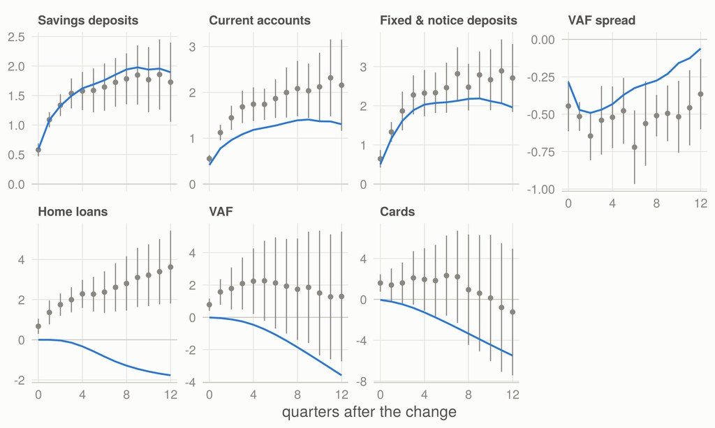

Response to a 1 pp repo change: local projection (points, 90% band) and the ARDL along the same repo path (line), quarterly. Deposit costs in percentage points; balances in % (the level of the book).

```r
lpq <- DY$lp[DY$lp$freq == "quarter", ]
lpq$lab <- factor(tlab[lpq$target], levels = unique(tlab[lpq$target]))
ggplot(lpq, aes(h)) +
  geom_hline(yintercept = 0, colour = ink[["axis"]], linewidth = 0.3) +
  geom_errorbar(aes(ymin = lo, ymax = hi), colour = ink[["muted"]], width = 0, linewidth = 0.4) +
  geom_point(aes(y = lp), colour = ink[["muted"]], size = 1.4) +
  geom_line(aes(y = ardl), colour = ent_col[["NGFB"]], linewidth = 0.7) +
  facet_wrap(~ lab, ncol = 4, scales = "free_y") +
  scale_x_continuous(breaks = c(0, 4, 8, 12)) +
  labs(x = "quarters after the change", y = NULL)
```

For savings and fixed deposits the two agree closely: the savings-deposit model’s response four quarters on is 1.62 pp against the local projection’s 1.58. Current accounts are the exception: along the same repo path the local projection finds 1.74 pp after four quarters and the model 1.18, below the projection’s band. If the projection is right, current-account costs follow the policy rate more closely than the model assumes, which would make NGFB somewhat more liability-sensitive than reported. For loan volumes they disagree, and instructively. The local projection says home-loan balances are *higher* after a rise (+2.3% four quarters on): it measures the correlation between rate changes and credit growth, and the SARB raises rates when credit is strong. It is model-free but not identification-free; the sign restriction is what identifies the causal direction in the satellites. A clean test would need monetary-policy shocks measured directly, for example from the movement of interest-rate futures around MPC announcements.

# 8 Stage 2: banks relative to the industry

## 8.1 Regimes and the share model

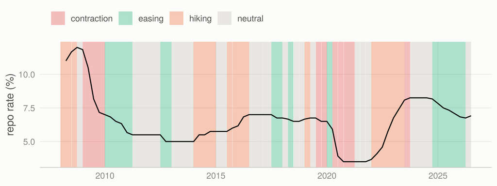

The repo rate with the macro regimes used in Stage 2. Contraction takes priority (real GDP down on a year earlier), then hiking or easing (the repo rate up or down at least 25 bps over two quarters).

```r
rgm <- S2$regimes
reg_col <- c(contraction = "#e34948", hiking = "#eb6834", easing = "#1baf7a", neutral = "#c3c2b7")
mm <- merge(rgm, P$macro[, c("date", "repo")], by = "date")
mm$start <- mm$date - 91
ggplot(mm) +
  geom_rect(aes(xmin = start, xmax = date, ymin = -Inf, ymax = Inf, fill = regime), alpha = 0.35) +
  geom_line(aes(date, repo), colour = ink[["primary"]], linewidth = 0.6) +
  scale_fill_manual(values = reg_col) +
  labs(x = NULL, y = "repo rate (%)")
```

For each peer group (and, internally, each large bank) and product, the annualised change in log market share is

$$400\,\Delta \log s_{t} = a + \delta_{\text{contr}}\, C_t + \delta_{\text{hike}}\, H_t + \delta_{\text{ease}}\, E_t + \kappa\,(g^{\text{sector}}_t - \bar g) + e_t ,$$

where $a$ is the structural share drift, the $\delta$s are the extra drift in each regime (neutral is the base), and $\kappa$ is the share’s sensitivity to the sector cycle: $\kappa > 0$ means the bank grows faster than the market in booms and shrinks faster in busts. The sample has 11 contraction, 18 hiking, 17 easing and 28 neutral quarters from 2008Q1.

Structural share drift a by peer group: percent a year of share growth, HAC t-statistics in brackets (— where a group’s share is too small to model).

| product | Big Four | Challengers | Specialists | Other |
| --- | --- | --- | --- | --- |
| Credit cards | -1.1 (-2.8) | +14.6 (2.7) | -5.5 (-2.2) | — |
| Personal and other retail | -1.1 (-0.7) | +2.9 (1.2) | -18.8 (-1.4) | +26.4 (1.9) |
| Residential mortgages | -0.3 (-4.0) | +11.0 (4.0) | +5.3 (4.0) | -8.1 (-1.0) |
| Corporate loans and overdrafts | +0.4 (1.0) | -1.7 (-0.1) | -2.2 (-0.6) | -3.4 (-0.9) |
| Non-maturity deposits | -0.1 (-0.2) | +13.4 (3.6) | -0.8 (-0.3) | -1.8 (-0.3) |
| Retail deposits (households) | -0.5 (-2.9) | +11.8 (5.2) | -0.8 (-0.4) | +1.0 (0.1) |
| Term deposits | +0.4 (0.6) | +0.1 (0.0) | -2.5 (-0.6) | -5.3 (-0.5) |

**All share-model coefficients (percent a year; HAC t in brackets; kappa per point of sector growth)**

| Product | Group | Drift a | Contraction | Hiking | Easing | Cycle kappa |
| --- | --- | --- | --- | --- | --- | --- |
| Corporate loans and overdrafts | Big Four | +0.4 (1.0) | +1.2 (2.1) | -0.4 (-0.5) | -0.9 (-1.2) | +0.0 (0.4) |
| Corporate loans and overdrafts | Challengers | -1.7 (-0.1) | +36.1 (2.1) | 0.0 (0.0) | +9.4 (0.6) | -1.0 (-1.8) |
| Corporate loans and overdrafts | Other | -3.4 (-0.9) | -11.3 (-1.7) | +1.6 (0.2) | +4.6 (0.6) | +0.4 (1.5) |
| Corporate loans and overdrafts | Specialists | -2.2 (-0.6) | -4.1 (-0.8) | +4.1 (0.7) | +4.4 (0.8) | -0.3 (-1.7) |
| Credit cards | Big Four | -1.1 (-2.8) | -0.5 (-0.7) | +1.3 (1.3) | -0.6 (-1.1) | +0.0 (0.7) |
| Credit cards | Challengers | +14.6 (2.7) | +12.1 (1.4) | -12.0 (-0.9) | +4.9 (0.6) | -0.6 (-0.9) |
| Credit cards | Specialists | -5.5 (-2.2) | +3.3 (1.0) | +4.4 (1.4) | +1.7 (0.2) | -0.5 (-1.8) |
| Non-maturity deposits | Big Four | -0.1 (-0.2) | -0.2 (-0.2) | -0.5 (-0.9) | +0.3 (0.6) | +0.0 (0.1) |
| Non-maturity deposits | Challengers | +13.4 (3.6) | -2.5 (-0.5) | -6.6 (-1.4) | -0.4 (-0.1) | -0.8 (-5.8) |
| Non-maturity deposits | Other | -1.8 (-0.3) | +6.6 (0.4) | +0.6 (0.1) | -6.9 (-0.8) | +0.6 (1.6) |
| Non-maturity deposits | Specialists | -0.8 (-0.3) | -2.4 (-0.4) | +7.1 (1.5) | +0.6 (0.1) | -0.4 (-3.4) |
| Personal and other retail | Big Four | -1.1 (-0.7) | -1.1 (-0.6) | +2.6 (1.2) | +0.5 (0.2) | -0.5 (-2.4) |
| Personal and other retail | Challengers | +2.9 (1.2) | +0.9 (0.3) | -3.3 (-0.9) | -0.6 (-0.2) | +0.8 (2.3) |
| Personal and other retail | Other | +26.4 (1.9) | -101.8 (-1.8) | -59.6 (-1.2) | -7.4 (-0.3) | -0.7 (-0.8) |
| Personal and other retail | Specialists | -18.8 (-1.4) | +12.2 (0.5) | +16.5 (1.1) | -3.4 (-0.1) | -0.3 (-0.4) |
| Residential mortgages | Big Four | -0.3 (-4.0) | +0.2 (1.3) | -0.1 (-0.7) | -0.2 (-2.0) | +0.0 (1.3) |
| Residential mortgages | Challengers | +11.0 (4.0) | -9.0 (-2.4) | +4.0 (0.9) | +4.6 (0.7) | +0.2 (0.3) |
| Residential mortgages | Other | -8.1 (-1.0) | -10.6 (-0.7) | +5.1 (0.3) | +6.6 (0.8) | 0.0 (0.0) |
| Residential mortgages | Specialists | +5.3 (4.0) | +0.2 (0.1) | +3.0 (1.2) | +2.9 (1.8) | -1.0 (-2.3) |
| Retail deposits (households) | Big Four | -0.5 (-2.9) | -0.5 (-1.7) | -0.7 (-1.8) | -0.5 (-1.6) | -0.1 (-1.9) |
| Retail deposits (households) | Challengers | +11.8 (5.2) | +5.4 (1.4) | -4.2 (-1.2) | +4.9 (1.0) | +0.3 (0.9) |
| Retail deposits (households) | Other | +1.0 (0.1) | -32.0 (-1.5) | +0.7 (0.1) | -10.4 (-0.8) | -0.1 (-0.1) |
| Retail deposits (households) | Specialists | -0.8 (-0.4) | +7.8 (1.0) | +9.8 (2.1) | +4.4 (1.0) | +0.2 (0.4) |
| Term deposits | Big Four | +0.4 (0.6) | -1.1 (-1.2) | 0.0 (0.0) | -1.9 (-2.3) | +0.1 (2.8) |
| Term deposits | Challengers | +0.1 (0.0) | +21.5 (3.6) | -5.6 (-0.7) | +14.7 (2.3) | -0.5 (-1.8) |
| Term deposits | Other | -5.3 (-0.5) | -19.9 (-1.1) | +3.6 (0.2) | +10.9 (0.6) | 0.0 (0.0) |
| Term deposits | Specialists | -2.5 (-0.6) | +9.6 (1.0) | +3.3 (0.5) | +10.5 (1.8) | -0.4 (-2.6) |

The structural drifts carry the clearest message: over 2008–2026 the Challengers took share at double-digit rates in cards, retail deposits and non-maturity deposits (all with $t > 2.5$), and the Big Four ceded it slowly but significantly in cards, retail deposits and mortgages. Regime effects are mostly imprecise, as is to be expected with only 11 contraction quarters, which is why they are pooled across banks and then truncated before they reach NGFB.

## 8.2 Who takes share from whom

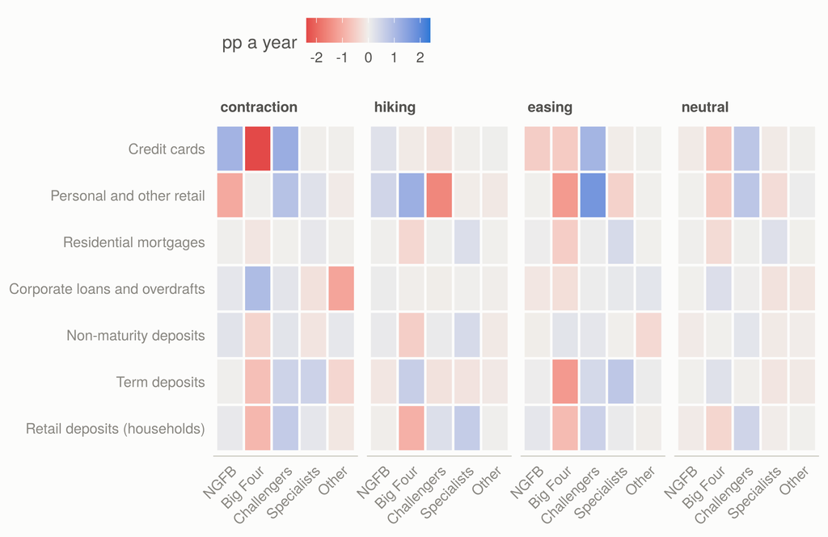

Average change in market share by regime, percentage points a year, with NGFB in the mix. Positive (blue) is a gain.

```r
rs <- N$regime_share
rs <- rs[rs$product %in% c(names(show_p), "dep_retail"), ]
rs$product <- factor(prod_lab[rs$product], levels = rev(prod_lab[c(names(show_p), "dep_retail")]))
rs$entity <- factor(rs$entity, levels = names(ent_col))
rs$regime <- factor(rs$regime, levels = c("contraction", "hiking", "easing", "neutral"))
lim <- max(abs(rs$ds_pp_yr), na.rm = TRUE)
ggplot(rs, aes(entity, product, fill = ds_pp_yr)) +
  geom_tile(colour = ink[["surface"]], linewidth = 0.8) +
  facet_wrap(~ regime, nrow = 1) +
  scale_fill_gradient2(low = div_lo, mid = div_mid, high = div_hi, midpoint = 0, limits = c(-lim, lim),
                       name = "pp a year") +
  labs(x = NULL, y = NULL) +
  theme(axis.text.x = element_text(angle = 45, hjust = 1), legend.title = element_text(colour = ink[["secondary"]]),
        panel.grid.major = element_blank())
```

**Table view (pp a year)**

| product | entity | contraction | easing | hiking | neutral |
| --- | --- | --- | --- | --- | --- |
| Corporate loans and overdrafts | Big Four | +0.98 | -0.25 | -0.02 | +0.31 |
| Corporate loans and overdrafts | Challengers | +0.20 | +0.06 | -0.04 | +0.03 |
| Corporate loans and overdrafts | NGFB | +0.18 | -0.14 | +0.07 | +0.00 |
| Corporate loans and overdrafts | Other | -1.14 | +0.19 | -0.03 | -0.14 |
| Corporate loans and overdrafts | Specialists | -0.21 | +0.13 | +0.02 | -0.20 |
| Credit cards | Big Four | -2.39 | -0.56 | -0.07 | -0.63 |
| Credit cards | Challengers | +1.26 | +1.12 | -0.20 | +0.78 |
| Credit cards | NGFB | +1.14 | -0.51 | +0.27 | -0.08 |
| Credit cards | Other | -0.01 | 0.00 | +0.02 | +0.00 |
| Credit cards | Specialists | -0.01 | -0.05 | -0.01 | -0.08 |
| Non-maturity deposits | Big Four | -0.42 | +0.21 | -0.50 | +0.00 |
| Non-maturity deposits | Challengers | +0.21 | +0.17 | +0.10 | +0.19 |
| Non-maturity deposits | NGFB | +0.23 | -0.03 | +0.11 | -0.07 |
| Non-maturity deposits | Other | +0.15 | -0.34 | -0.09 | -0.05 |
| Non-maturity deposits | Specialists | -0.17 | -0.01 | +0.39 | -0.08 |
| Personal and other retail | Big Four | +0.01 | -1.30 | +1.24 | -0.55 |
| Personal and other retail | Challengers | +0.86 | +1.74 | -1.57 | +0.78 |
| Personal and other retail | NGFB | -1.06 | +0.00 | +0.49 | 0.00 |
| Personal and other retail | Other | -0.07 | +0.00 | -0.10 | +0.06 |
| Personal and other retail | Specialists | +0.26 | -0.45 | -0.05 | -0.29 |
| Residential mortgages | Big Four | -0.15 | -0.52 | -0.36 | -0.31 |
| Residential mortgages | Challengers | +0.00 | +0.06 | +0.02 | +0.02 |
| Residential mortgages | NGFB | +0.02 | +0.05 | +0.02 | +0.01 |
| Residential mortgages | Other | -0.02 | +0.00 | +0.01 | -0.01 |
| Residential mortgages | Specialists | +0.14 | +0.40 | +0.31 | +0.28 |
| Retail deposits (households) | Big Four | -0.86 | -0.79 | -0.96 | -0.39 |
| Retail deposits (households) | Challengers | +0.68 | +0.56 | +0.30 | +0.50 |
| Retail deposits (households) | NGFB | +0.13 | +0.17 | -0.03 | -0.07 |
| Retail deposits (households) | Other | -0.13 | -0.03 | +0.02 | 0.00 |
| Retail deposits (households) | Specialists | +0.18 | +0.09 | +0.67 | -0.04 |
| Term deposits | Big Four | -0.73 | -1.31 | +0.62 | +0.26 |
| Term deposits | Challengers | +0.53 | +0.42 | -0.20 | -0.01 |
| Term deposits | NGFB | +0.02 | +0.05 | -0.14 | 0.00 |
| Term deposits | Other | -0.38 | +0.08 | -0.10 | -0.10 |
| Term deposits | Specialists | +0.55 | +0.75 | -0.18 | -0.15 |

Net share changes do not say who lost to whom: a two-point gain could come from one competitor or from all of them. The flow matrices below use a labelled convention, giving each gainer’s gain to the losers in proportion to their losses.

Credit cards in contractions: share gained (rows) from each loser (columns), pp a year.

| gains | Big Four | Challengers | NGFB | Other | Specialists |
| --- | --- | --- | --- | --- | --- |
| Challengers | 1.25 | 0 | 0 | 0.01 | 0 |
| NGFB | 1.13 | 0 | 0 | 0.01 | 0 |

Non-maturity deposits in hiking regimes: share gained (rows) from each loser (columns), pp a year.

| gains | Big Four | Challengers | NGFB | Other | Specialists |
| --- | --- | --- | --- | --- | --- |
| Challengers | 0.08 | 0 | 0 | 0.01 | 0 |
| NGFB | 0.09 | 0 | 0 | 0.02 | 0 |
| Specialists | 0.33 | 0 | 0 | 0.06 | 0 |

In contractions the Big Four lose card share to the Challengers and to NGFB; in hiking regimes non-maturity deposits move from the Big Four towards the Specialists, with NGFB and the Challengers smaller gainers. NGFB’s rows follow from its drawn parameters below, so they describe the kind of bank NGFB is, not data about any real bank.

## 8.3 NGFB’s share parameters

Random-effects (DerSimonian–Laird) pooling across the six large banks and NGFB’s posterior-predictive draw (seed 20260622), truncated at the same central probability mass as Post 1. Only pooled hyperparameters are shown.

| Product | Parameter | Population mean | Between-bank s.d. | s.e. of mean | Banks | NGFB |
| --- | --- | --- | --- | --- | --- | --- |
| Credit cards | (Intercept) | -1.55 | 3.44 | 1.79 | 5 | -4.90 |
| Credit cards | contraction | -1.36 | 6.01 | 3.16 | 5 | 3.79 |
| Credit cards | hiking | 1.21 | 0.00 | 1.07 | 5 | 1.43 |
| Credit cards | easing | -1.28 | 4.25 | 2.48 | 5 | -1.96 |
| Credit cards | kappa | -0.41 | 0.27 | 0.16 | 5 | -0.34 |
| Non-maturity deposits | (Intercept) | 0.77 | 2.26 | 1.22 | 6 | 1.94 |
| Non-maturity deposits | contraction | 0.48 | 0.00 | 1.14 | 6 | 0.41 |
| Non-maturity deposits | hiking | 0.22 | 0.12 | 1.12 | 6 | 0.60 |
| Non-maturity deposits | easing | -0.02 | 0.00 | 1.10 | 6 | -0.01 |
| Non-maturity deposits | kappa | -0.19 | 0.30 | 0.14 | 6 | -0.47 |
| Personal and other retail | (Intercept) | 0.39 | 5.59 | 2.79 | 6 | 1.25 |
| Personal and other retail | contraction | 0.70 | 9.96 | 4.98 | 6 | -6.16 |
| Personal and other retail | hiking | 2.85 | 0.00 | 1.93 | 6 | 2.17 |
| Personal and other retail | easing | 0.83 | 0.00 | 2.18 | 6 | 0.72 |
| Personal and other retail | kappa | -0.39 | 0.28 | 0.17 | 6 | -0.14 |

Each parameter is pooled across the six large banks with a random-effects (DerSimonian–Laird) estimator, and NGFB’s vector is drawn from the posterior predictive $N(\mu, \tau^2 + \text{se}_\mu^2)$, truncated to the same central probability mass as Post 1 (radius 1.53 in five dimensions). Only pooled quantities with at least four banks are used. NGFB’s **structural drift is switched off** in all projections: a drawn drift of a few percent a year compounds into large, arbitrary share gains or losses over a horizon, and the question here is how NGFB responds to the *cycle*.

# 9 Scenarios

The three scenarios, and the downside’s policy-rate variant. Probabilities are judgemental and are used only for the probability-weighted positioning.

| Scenario | Narrative | Probability |
| --- | --- | --- |
| Baseline | Inflation peaks above 5% around the turn of the year and returns to the 3% target by late 2027; the repo rate holds at 7.25% and then eases gradually to 6.25%; growth settles at about 1.6%. | 50% |
| Upside: faster disinflation and a growth dividend | Oil and food prices ease and inflation returns to the 3% target early; the SARB cuts a further 100 bps; terms-of-trade gains and electricity and logistics reform lift growth to about 3%; the rand firm… | 20% |
| Downside: stagflationary shock | A fiscal slippage and a rand sell-off push inflation above 6%; the SARB hikes a further 150 bps and the long bond sells off about 200 bps; the economy contracts for two years, unemployment rises 2.5 p… | 30% |
| Downside with cuts: demand-led recession | The same contraction as the downside, but inflation falls and the SARB cuts a further 150 bps instead of hiking. | variant |

The baseline starts from the realised data at 2026Q2 and follows the SARB’s own guidance for the next year: the repo rate at 7.25% after the September 2026 increase, inflation above 5% around the turn of the year and back at the 3% target (adopted with a one-point tolerance band in November 2025) by late 2027, after which the policy rate eases gradually to a 6.25% neutral level. Growth converges to about 1.6%. The upside and the downside are shocks layered on the baseline with build-up, hold and decay profiles; the derived variables (prime, JIBAR, curve slope, real rates, rate changes and their partial sums) are recomputed from the shocked paths, so every scenario is internally consistent.

The **downside** is deliberately stagflationary. The SARB’s own 2023 common scenario stress test built its domestic adverse scenario the same way: a higher country risk premium and a sharply weaker rand push inflation up, the SARB tightens, government bond yields reprice and the economy contracts. The alternative, a demand-led recession in which inflation falls and the SARB cuts (2009, 2020), is run as a **variant** with the same real shock, because for a hedged bank the policy response decides the sign of the rate effect.

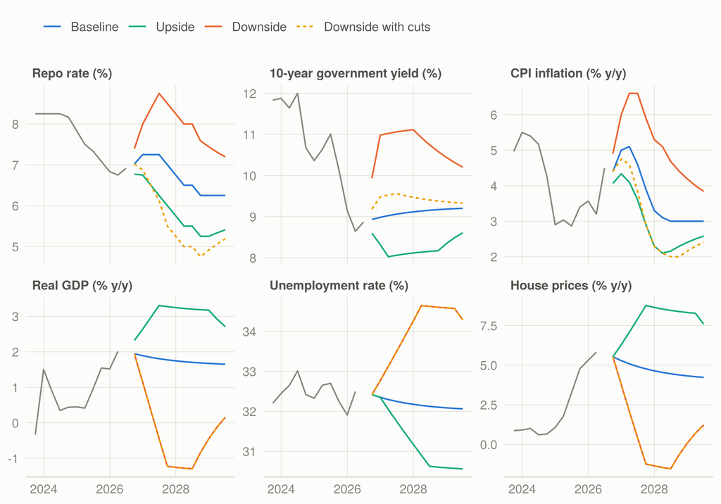

Macro paths by scenario (history in grey). The dashed line is the downside’s variant with rate cuts.

```r
mv_lab <- c(repo = "Repo rate (%)", gov10y = "10-year government yield (%)", cpi_yy = "CPI inflation (% y/y)",
            gdp_yy = "Real GDP (% y/y)", unemp = "Unemployment rate (%)", hpi_yy = "House prices (% y/y)")
hh <- P$macro[P$macro$date <= date0 & P$macro$date > date0 - 365 * 3, c("date", names(mv_lab))]
hl <- do.call(rbind, lapply(names(mv_lab), function(v) data.frame(date = hh$date, var = v, value = hh[[v]])))
sl <- do.call(rbind, lapply(names(lib), function(k) do.call(rbind, lapply(names(mv_lab), function(v)
  data.frame(date = lib[[k]]$date, var = v, value = lib[[k]][[v]], scenario = k)))))
hl$var <- factor(mv_lab[hl$var], levels = mv_lab); sl$var <- factor(mv_lab[sl$var], levels = mv_lab)
sl$scenario <- factor(sl$scenario, levels = names(sc_col))
ggplot() +
  geom_line(data = hl[is.finite(hl$value), ], aes(date, value), colour = ink[["muted"]], linewidth = 0.55) +
  geom_line(data = sl, aes(date, value, colour = scenario, linetype = scenario), linewidth = 0.6) +
  facet_wrap(~ var, ncol = 3, scales = "free_y") +
  scale_colour_manual(values = sc_col, labels = sc_short) +
  scale_linetype_manual(values = c(baseline = "solid", upside = "solid", downside = "solid", downside_cuts = "22"),
                        labels = sc_short) +
  labs(x = NULL, y = NULL)
```

**Table view**

| Scenario | Repo, peak | Repo, end | GDP y/y, trough | GDP y/y, average | CPI y/y, peak | Unemployment, peak | House prices y/y, trough | 10-year, peak |
| --- | --- | --- | --- | --- | --- | --- | --- | --- |
| Baseline | 7.25 | 6.25 | 1.7 | 1.8 | 5.1 | 32.4 | 4.2 | 9.20 |
| Upside | 6.77 | 5.41 | 2.3 | 3.0 | 4.3 | 32.4 | 5.5 | 8.61 |
| Downside | 8.75 | 7.19 | -1.3 | -0.3 | 6.6 | 34.6 | -1.5 | 11.12 |
| Downside with cuts | 7.02 | 5.19 | -1.3 | -0.3 | 4.8 | 34.6 | -1.5 | 9.56 |

## 9.1 What the scenarios do to the industry and to NGFB

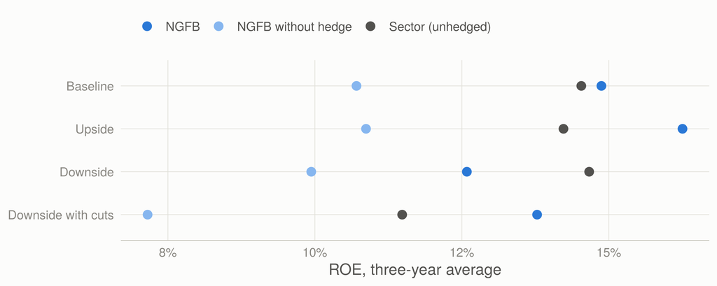

Three-year average ROE by scenario: NGFB with its hedge, NGFB without it, and the BA900 sector through the same engine (unhedged).

```r
rl <- rbind(data.frame(scenario = sumtab$scenario, who = "NGFB", roe = sumtab$ngfb),
            data.frame(scenario = sumtab$scenario, who = "NGFB without hedge", roe = sumtab$ngfb_nohedge),
            data.frame(scenario = sumtab$scenario, who = "Sector (unhedged)", roe = sumtab$sector))
rl$scenario <- factor(sc_short[rl$scenario], levels = rev(sc_short))
ggplot(rl, aes(roe, scenario, colour = who)) +
  geom_point(size = 3) +
  scale_colour_manual(values = c(NGFB = ent_col[["NGFB"]], `NGFB without hedge` = "#86b6ef",
                                 `Sector (unhedged)` = ink[["secondary"]])) +
  scale_x_continuous(labels = scales::percent_format(1)) +
  labs(x = "ROE, three-year average", y = NULL)
```

Change against the baseline, by channel: three-year average ROE and three-year net income. Each channel swaps one block of engine inputs from the scenario into the baseline run; the interaction is the residual.

| Scenario | Entity | Metric | Volume | Pricing (incl. hedge) | Credit | Fees and costs | Interaction | Total |
| --- | --- | --- | --- | --- | --- | --- | --- | --- |
| Upside | NGFB | ROE | -4 bps | +43 bps | +99 bps | +1 bps | -1 bps | +138 bps |
| Upside | NGFB | Net income, 3 years | -R0.2 bn | +R1.7 bn | +R3.9 bn | +R0.1 bn | +R0.0 bn | +R5.5 bn |
| Upside | Sector | ROE | +4 bps | -105 bps | +69 bps | +1 bps | +1 bps | -30 bps |
| Upside | Sector | Net income, 3 years | +R0.9 bn | -R26.7 bn | +R17.7 bn | +R0.4 bn | +R0.0 bn | -R7.7 bn |
| Downside | NGFB | ROE | +5 bps | -72 bps | -162 bps | -2 bps | +2 bps | -229 bps |
| Downside | NGFB | Net income, 3 years | +R0.2 bn | -R2.8 bn | -R6.3 bn | -R0.1 bn | +R0.2 bn | -R8.9 bn |
| Downside | Sector | ROE | -4 bps | +129 bps | -112 bps | -2 bps | +2 bps | +13 bps |
| Downside | Sector | Net income, 3 years | -R1.1 bn | +R33.4 bn | -R28.4 bn | -R0.5 bn | +R0.1 bn | +R3.4 bn |
| Downside with cuts | NGFB | ROE | +4 bps | +35 bps | -137 bps | -17 bps | +5 bps | -109 bps |
| Downside with cuts | NGFB | Net income, 3 years | +R0.2 bn | +R1.4 bn | -R5.3 bn | -R0.7 bn | +R0.2 bn | -R4.3 bn |
| Downside with cuts | Sector | ROE | +5 bps | -195 bps | -95 bps | -17 bps | -4 bps | -305 bps |
| Downside with cuts | Sector | Net income, 3 years | +R1.2 bn | -R49.0 bn | -R24.0 bn | -R4.2 bn | +R0.0 bn | -R76.2 bn |

The industry is an **endowment play**. Without a hedge, its deposits and capital earn more when rates rise, so in the downside the higher repo path adds +129 bps to the sector’s ROE and offsets the credit losses (-112 bps); in the upside the cuts take -105 bps away and the better credit picture only partly compensates. NGFB is a **credit play**, and in this version a slightly **liability-sensitive** one. Its unsecured-heavy book makes credit its largest channel (-162 bps in the downside, +99 bps in the upside), and its receive-fixed hedge, sized for slower deposit repricing than the refined models now find, more than offsets its endowment: higher rates cost it 72 bps in the downside, and lower rates add 43 bps in the upside. In net income the downside costs NGFB R8.9 bn over three years (R6.3 bn of it credit), while the sector, 6.3 times NGFB’s size in earnings, makes +R3.4 bn.

The **variant** shows how much rides on the policy response. With the same contraction but rate cuts, the hedge earns +35 bps for NGFB, which loses 109 bps in total, about half the stagflationary loss, while the unhedged sector loses 305 bps. A structural hedge protects against the downturns of 2009 and 2020; it does not protect against a downturn that comes with hikes.

The hedge also explains why NGFB’s *level* of ROE sits above the sector’s. In the baseline NGFB earns 14.9% with its hedge and 10.7% without it: the receive-fixed book carries an average fixed rate of 8.87%, locked in over the past five years, against a JIBAR path averaging 6.73% over the horizon, and new swaps are struck at a term premium over JIBAR. Unhedged, NGFB earns less than the sector because its credit losses are higher. The carry is the value of a position taken when rates were higher, not a free lunch: it is what the hedge pays for giving up the upside in a hiking cycle.

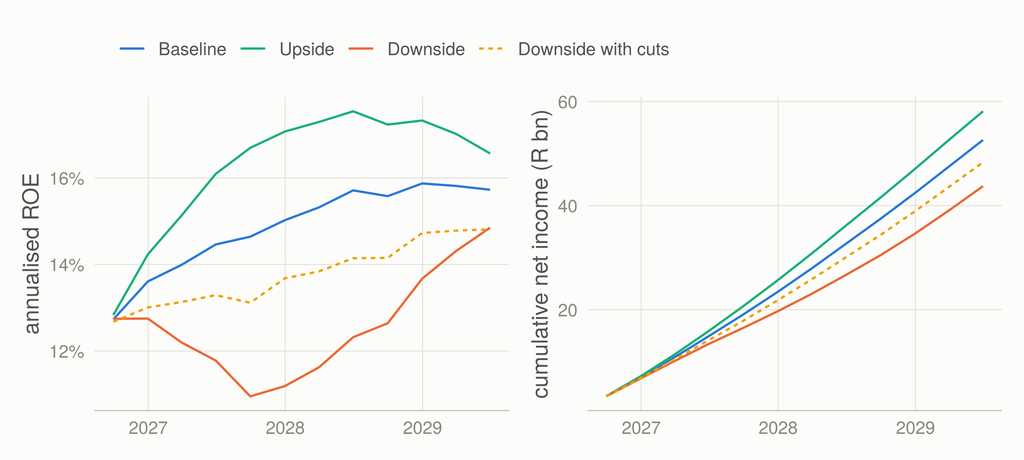

NGFB’s quarterly ROE and cumulative net income by scenario.

```r
rp <- do.call(rbind, lapply(names(allr), function(k) { q <- allr[[k]]$ngfb$run$quarterly
  data.frame(date = q$date, roe = q$roe, ni = cumsum(q$net_income), scenario = k) }))
rp$scenario <- factor(rp$scenario, levels = names(sc_col))
p1 <- ggplot(rp, aes(date, roe, colour = scenario, linetype = scenario)) +
  geom_line(linewidth = 0.6) +
  scale_colour_manual(values = sc_col, labels = sc_short) +
  scale_linetype_manual(values = c(baseline = "solid", upside = "solid", downside = "solid", downside_cuts = "22"),
                        labels = sc_short) +
  scale_y_continuous(labels = scales::percent_format(1)) +
  labs(x = NULL, y = "annualised ROE")
p2 <- ggplot(rp, aes(date, ni / 1e6, colour = scenario, linetype = scenario)) +
  geom_line(linewidth = 0.6) +
  scale_colour_manual(values = sc_col, labels = sc_short) +
  scale_linetype_manual(values = c(baseline = "solid", upside = "solid", downside = "solid", downside_cuts = "22"),
                        labels = sc_short) +
  labs(x = NULL, y = "cumulative net income (R bn)")
if (requireNamespace("patchwork", quietly = TRUE)) {
  print(patchwork::wrap_plots(p1, p2, ncol = 2, guides = "collect") & theme(legend.position = "top"))
} else print(p1)
```

**Table view: quarterly ROE / cumulative net income**

| Quarter | Baseline | Upside | Downside | Downside with cuts |
| --- | --- | --- | --- | --- |
| 2026Q3 | 12.7% / R3.4 bn | 12.8% / R3.4 bn | 12.7% / R3.4 bn | 12.7% / R3.4 bn |
| 2026Q4 | 13.6% / R7.0 bn | 14.2% / R7.2 bn | 12.7% / R6.8 bn | 13.0% / R6.9 bn |
| 2027Q1 | 14.0% / R10.9 bn | 15.1% / R11.4 bn | 12.2% / R10.2 bn | 13.1% / R10.5 bn |
| 2027Q2 | 14.5% / R14.9 bn | 16.1% / R15.9 bn | 11.8% / R13.4 bn | 13.3% / R14.2 bn |
| 2027Q3 | 14.6% / R19.1 bn | 16.7% / R20.7 bn | 11.0% / R16.5 bn | 13.1% / R17.9 bn |
| 2027Q4 | 15.0% / R23.4 bn | 17.1% / R25.7 bn | 11.2% / R19.7 bn | 13.7% / R21.8 bn |
| 2028Q1 | 15.3% / R28.0 bn | 17.3% / R30.8 bn | 11.6% / R23.1 bn | 13.8% / R25.9 bn |
| 2028Q2 | 15.7% / R32.7 bn | 17.5% / R36.2 bn | 12.3% / R26.7 bn | 14.1% / R30.1 bn |
| 2028Q3 | 15.6% / R37.5 bn | 17.2% / R41.6 bn | 12.6% / R30.5 bn | 14.2% / R34.4 bn |
| 2028Q4 | 15.9% / R42.4 bn | 17.3% / R47.1 bn | 13.7% / R34.6 bn | 14.7% / R38.9 bn |
| 2029Q1 | 15.8% / R47.5 bn | 17.0% / R52.6 bn | 14.3% / R39.1 bn | 14.8% / R43.6 bn |
| 2029Q2 | 15.7% / R52.6 bn | 16.6% / R58.1 bn | 14.9% / R43.7 bn | 14.8% / R48.3 bn |

Capital and liquidity are not the constraint in any scenario: NGFB’s CET1 ratio never falls below 12.8% (management floor 11.5%), and its LCR proxy never below 183% (floor 120%).

## 9.2 Model risk in the scenarios

NGFB’s three-year average ROE and net income under two alternative credit models (changes against the core in brackets).

| Scenario | Core ROE | Credit losses convex in a contraction | No intercept correction on credit losses | Core net income | Convex: net income | No credit correction: net income |
| --- | --- | --- | --- | --- | --- | --- |
| Baseline | 14.9% | 14.9% (+1 bps) | 13.4% (-144 bps) | R52.6 bn | +R0.0 bn | -R5.6 bn |
| Upside | 16.3% | 15.8% (-42 bps) | 14.8% (-141 bps) | R58.1 bn | -R1.7 bn | -R5.6 bn |
| Downside | 12.6% | 12.6% (+6 bps) | 11.1% (-147 bps) | R43.7 bn | +R0.2 bn | -R5.5 bn |

Two credit-model choices deserve a flag. If losses are convex in a contraction (the kinked model from the model checks), growth above zero no longer lowers them, so the upside’s credit benefit shrinks (-42 bps of ROE), while the downside barely changes because its two years of negative growth produce about the same losses either way. And the intercept correction on the credit-loss ratio, which carries the industry’s recent better-than-modelled loss experience forward, is worth 144 bps of ROE in every scenario: it moves the level of NGFB’s returns, not the differences between scenarios, and not the positioning.

# 10 Sensitivities

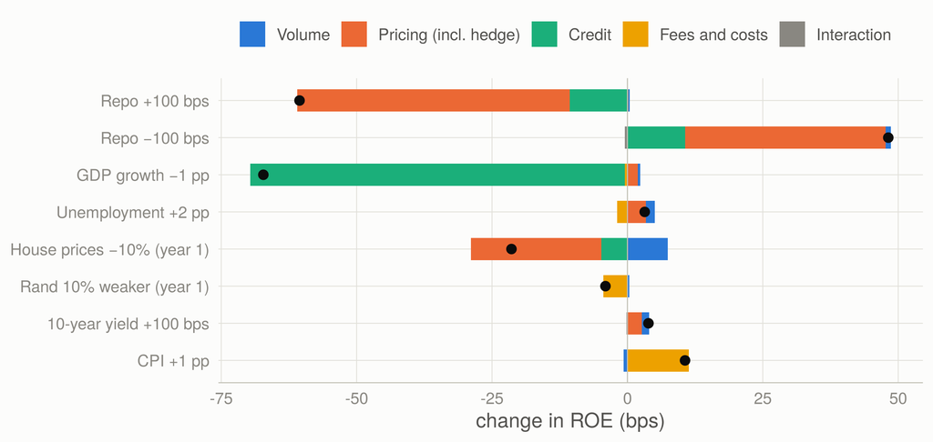

NGFB’s three-year average ROE response to one-variable shocks around the baseline, by channel. The dot is the total.

```r
sh_lab <- c(repo_up_100 = "Repo +100 bps", repo_down_100 = "Repo −100 bps", gdp_down_1 = "GDP growth −1 pp",
            unemp_up_2 = "Unemployment +2 pp", hpi_down_10 = "House prices −10% (year 1)",
            zar_weaker_10 = "Rand 10% weaker (year 1)", gov10y_up_100 = "10-year yield +100 bps",
            cpi_up_1 = "CPI +1 pp")
ch_lab <- c(volume = "Volume", pricing = "Pricing (incl. hedge)", credit = "Credit", fees_costs = "Fees and costs",
            interaction = "Interaction")
sl2 <- do.call(rbind, lapply(names(ch_lab), function(k) data.frame(shock = sens$shock, channel = k, v = sens[[k]])))
sl2$shock <- factor(sh_lab[sl2$shock], levels = rev(sh_lab)); sl2$channel <- factor(ch_lab[sl2$channel], levels = ch_lab)
tot <- data.frame(shock = factor(sh_lab[sens$shock], levels = rev(sh_lab)), v = sens$total)
ggplot(sl2, aes(1e4 * v, shock, fill = channel)) +
  geom_col(width = 0.6) +
  geom_point(data = tot, aes(1e4 * v, shock), inherit.aes = FALSE, size = 2.4, colour = ink[["primary"]]) +
  geom_vline(xintercept = 0, colour = ink[["axis"]], linewidth = 0.3) +
  scale_fill_manual(values = c(unname(pal$categorical[1:4]), ink[["muted"]])) +
  labs(x = "change in ROE (bps)", y = NULL)
```

**Table view**

| Shock | Total | Net income, 3 years | Volume | Pricing | Credit | Fees and costs | NIM | Credit-loss ratio | CET1, end | Total without hedge |
| --- | --- | --- | --- | --- | --- | --- | --- | --- | --- | --- |
| Repo +100 bps | -61 bps | -R2,379 m | +0 bps | -50 bps | -11 bps | +0 bps | -6 bps | +1 bps | +7 bps | +128 bps |
| Repo −100 bps | +48 bps | +R1,908 m | +1 bps | +37 bps | +11 bps | +0 bps | +5 bps | -1 bps | +0 bps | -141 bps |
| GDP growth −1 pp | -67 bps | -R2,640 m | +0 bps | +2 bps | -69 bps | -1 bps | +0 bps | +11 bps | -6 bps | -72 bps |
| Unemployment +2 pp | +3 bps | +R126 m | +2 bps | +3 bps | +0 bps | -2 bps | +1 bps | -1 bps | +8 bps | +3 bps |
| House prices −10% (year 1) | -21 bps | -R844 m | +7 bps | -24 bps | -5 bps | +0 bps | -1 bps | +1 bps | +8 bps | -23 bps |
| Rand 10% weaker (year 1) | -4 bps | -R160 m | +0 bps | +0 bps | +0 bps | -4 bps | +0 bps | +0 bps | +1 bps | -4 bps |
| 10-year yield +100 bps | +4 bps | +R153 m | +1 bps | +3 bps | +0 bps | +0 bps | +1 bps | +0 bps | +4 bps | -36 bps |
| CPI +1 pp | +11 bps | +R420 m | -1 bps | +0 bps | +0 bps | +11 bps | +0 bps | +1 bps | -6 bps | +11 bps |

The sensitivities answer “how exposed are we” one variable at a time (one basis point of ROE is about R12 m of net income a year):

- **Rates.** ±100 bps on the repo path moves NGFB’s ROE by -61 bps / +48 bps (-R2,379 m / +R1,908 m of net income over three years). Without the hedge the same shocks would move it by +128 bps / -141 bps. The hedge, 49.6% of non-maturity deposits, was sized in Post 3 for slower deposit repricing than the refined Stage 1 models find, so it now more than neutralises the endowment and leaves NGFB modestly liability-sensitive. A rate rise also costs 11 bps through credit losses.
- **Growth.** One point less GDP growth for three years costs 67 bps (-R2,640 m), almost all of it through credit losses (-69 bps). This is NGFB’s largest single exposure.
- **House prices** matter through mortgage and VAF pricing and credit (-21 bps for a 10% fall in the first year).
- **Inflation** helps a little (+11 bps per point) because fee income tracks nominal activity.
- **Unemployment** has essentially no effect (+3 bps): no credit-loss specification with unemployment survives the sign and t-tests, so the engine has no unemployment channel. Unemployment is not harmless; the South African series is too slow-moving and too noisy, given GDP, to identify one.

# 11 Positioning before the scenario arrives

## 11.1 The optimisation problem

The decision is a set of balance-sheet moves made at the jump-off: transfers of one percent of total assets from HQLA (the liquidity numeraire) into a lending book, from wholesale funding into a deposit category, or a change in the receive-fixed hedge of one percent of the non-maturity deposit (NMD) base. The full engine is the source of truth; around the status quo it is close to linear in the moves, so for every scenario $s$ the ROE gradient $G_s$ and the gradients of the CET1 and LCR troughs and of net income come from central finite differences.

A naive optimiser would simply maximise the engine’s ROE. Even with the execution costs below it grows every lending book out of HQLA, pushes 5 of the six to their upper bound and claims 372 bps of probability-weighted ROE: the engine prices new volume at the book’s *average* yield, loss rate and cost ratio, and holds equity fixed, so any risk asset looks better than HQLA. That static attractiveness is a franchise and capacity question (marginal pricing, cost to serve, adverse selection) that public data cannot price. The positioning question is different: *what should change because scenario X is coming?*

The answer used here treats the status quo as optimal under the baseline (the balance sheet reflects the bank’s central plan). That reveals an implied marginal cost for every move, $c = G_{\text{baseline}}$, in the same way Black and Litterman back out implied returns from market weights. Positioning then trades on how a scenario changes each move’s value:

$$\max_x \; \sum_s w_s \big(R_s + (G_s - c)\,x\big) \;-\; \tfrac{\lambda}{2}\, \mathrm{Var}_w\!\big(R + G x\big) \;-\; \tfrac12\, x' K x$$

subject to the CET1 floor (11.5%), the LCR floor (120%) and move bounds, where $K$ is an execution cost: pricing concessions and acquisition costs to grow a book within a year, attrition to shrink it. With one scenario treated as certain ($w_X = 1$, $\lambda = 0$) and no constraint binding, the problem separates move by move and has a closed form:

$$x_k^{*} = \frac{G_{X,k} - c_k}{2\,\kappa_k}, \qquad \text{net gain} = \sum_k \frac{(G_{X,k} - c_k)^2}{4\,\kappa_k},$$

where $\kappa_k$ is the execution cost of a one-unit move. Every result is re-run through the full engine and reported net of $c'x$ and $\tfrac12 x'Kx$, in ROE and in net income (the implied cost in net-income terms is the net-income gradient under the baseline, so the status quo is optimal in both). The quadratic programme’s linear prediction and the engine agree to within 0.24 bps of ROE.

Moves, bounds and costs. The last two columns are what the engine says each move earns under the baseline before any marginal cost (net income over three years); the optimiser treats them as the move’s implied marginal cost.

| Move | From | Unit | Bounds | Execution cost of a 1-unit move | Engine ROE gain per unit, baseline (= implied cost) | Net income per unit, baseline |
| --- | --- | --- | --- | --- | --- | --- |
| Residential mortgages | HQLA | 1% of assets | -2.0 to +2.0 | 8.0 bps | +39.1 bps | +R1,544 m |
| Vehicle and asset finance | HQLA | 1% of assets | -2.0 to +1.5 | 8.0 bps | +40.5 bps | +R1,599 m |
| Credit cards | HQLA | 1% of assets | -1.5 to +1.0 | 15.0 bps | +56.4 bps | +R2,225 m |
| Personal loans | HQLA | 1% of assets | -1.5 to +1.0 | 15.0 bps | +58.7 bps | +R2,316 m |
| Corporate loans | HQLA | 1% of assets | -2.0 to +2.0 | 8.0 bps | +45.9 bps | +R1,814 m |
| Commercial property | HQLA | 1% of assets | -1.5 to +1.5 | 8.0 bps | +34.5 bps | +R1,363 m |
| Term deposits | Wholesale funding | 1% of assets | -2.0 to +2.0 | 4.0 bps | +7.1 bps | +R278 m |
| Savings deposits | Wholesale funding | 1% of assets | -1.0 to +1.0 | 8.0 bps | +16.5 bps | +R652 m |
| Transactional deposits | Wholesale funding | 1% of assets | -1.0 to +1.0 | 12.0 bps | +30.4 bps | +R1,201 m |
| Structural hedge | — | 1% of NMD | -25.0 to +25.0 | 0.2 bps | +8.1 bps | +R322 m |

The hedge is bounded by policy (a hedge ratio of roughly 25–75% of NMD) and penalised for deviating from Post 3’s variance-optimal ratio rather than for transaction costs, which are negligible for swaps.

## 11.2 How the problem is solved, step by step

For every scenario the same eight steps run, in `analysis/05_scenarios.R` and `analysis/06_optimise.R`:

1. **Project the scenario.** The macro path drives the Stage 1 sector models (volumes, spreads, deposit costs, credit losses, fees, costs) and the Stage 2 share models (NGFB’s growth relative to the sector, by regime).
2. **Run the status quo.** The engine projects NGFB’s balance sheet, P&L, capital and liquidity quarter by quarter: ROE $R_s$, net income, CET1 and LCR troughs.
3. **Measure the gradients.** Each move is made at ±0.5 units and the engine re-run: $G_{s,k} = (\text{ROE}^{+} - \text{ROE}^{-})/1$, and likewise for net income, CET1 and LCR.
4. **Back out the implied costs.** $c_k = G_{\text{baseline},k}$: the plan is built for the baseline, so at the margin no move adds value there.
5. **Net gradient.** $G_{s,k} - c_k$ is what scenario $s$ changes about the value of move $k$.
6. **Solve.** The quadratic programme (`quadprog`’s dual active-set method) maximises net gradient times moves less execution cost, subject to the bounds and the CET1 and LCR floors. When nothing binds the solution is the closed form above, one line per move.
7. **Re-run and bridge.** The engine is re-run with the moves, which captures everything the linear model misses (moves compound with growth, equity builds); each move’s contribution is measured sequentially, net of its implied and execution cost, so the bars add up to the total.
8. **Score the alternatives.** The same moves are evaluated under every other scenario: the cost of being wrong.

## 11.3 The baseline: what NGFB does in its plan

NGFB’s baseline plan by year. Amounts in R bn; flows are annual totals.

| Item | Year 1 (to 2027Q2) | Year 2 (to 2028Q2) | Year 3 (to 2029Q2) |
| --- | --- | --- | --- |
| Total assets, year end | 1,549 | 1,649 | 1,765 |
| Loans, year end | 966 | 1,029 | 1,101 |
| Deposits, year end | 1,235 | 1,310 | 1,390 |
| Net interest income | 43.9 | 49.2 | 54.0 |
| of which hedge carry | 5.4 | 6.7 | 7.5 |
| Non-interest revenue | 33.3 | 36.0 | 38.1 |
| Operating costs | 45.2 | 48.5 | 51.6 |
| Credit impairments | 12.9 | 14.0 | 14.9 |
| Profit before tax | 19.1 | 22.8 | 25.5 |
| Net income | 14.9 | 17.8 | 19.9 |
| ROE (average) | 13.7% | 15.2% | 15.7% |
| NIM (average) | 3.23% | 3.39% | 3.48% |
| Credit-loss ratio (average) | 1.39% | 1.40% | 1.40% |
| CET1 ratio, year end | 13.0% | 13.1% | 13.3% |
| LCR, trough | 189% | 187% | 186% |

In the baseline NGFB does not reposition; it runs its plan. The balance sheet grows about 7% a year, the sector’s projected growth plus NGFB’s regime-dependent share dynamics, line by line. Loans reprice with prime and JIBAR plus the sector’s projected spreads; deposits reprice with the Stage 1 deposit costs. One twentieth of the receive-fixed hedge rolls off every quarter and is replaced at the then five-year swap rate, so the hedge’s average fixed rate drifts down slowly from 8.87% while JIBAR falls faster, and the hedge carry grows from R5.4 bn in year one to R7.5 bn in year three. Credit losses follow the sector’s loss ratio scaled by NGFB’s product mix (1.40% of loans against the sector’s 0.89%); fees and costs follow the sector’s ratios to assets. Half of net income is paid out, so CET1 builds from 13.0% to 13.3% and ROE rises each year as the margin widens with the easing cycle, from 13.7% to 15.7%. The positioning for the baseline is zero by construction: the plan is optimal for the scenario it was built for.

## 11.4 The downside, step by step

**1. The macro path.** The repo rate rises from the baseline’s 7.25% peak to 8.75% by 2027Q2, inflation peaks at 6.6%, the long bond at 11.12%, and real GDP contracts for 8 quarters, troughing at -1.3% year on year; unemployment peaks at 34.6% and house prices fall.

**2. What the industry does (Stage 1).**

The sector’s projected paths in the downside against the baseline.

| Industry (Stage 1), three-year average | Baseline | Scenario | Change |
| --- | --- | --- | --- |
| Residential mortgages, growth (% a year) | 3.86 | 3.32 | -0.55 |
| Credit cards, growth | 7.78 | 5.14 | -2.65 |
| Personal loans, growth | 5.91 | 5.42 | -0.48 |
| Corporate loans, growth | 9.01 | 6.96 | -2.06 |
| Non-maturity deposits, growth | 7.13 | 6.24 | -0.89 |
| Credit-loss ratio (% of loans) | 0.88 | 1.05 | +0.16 |
| Cost of current accounts (%) | 3.33 | 3.96 | +0.63 |
| Cost of savings deposits (%) | 6.22 | 7.09 | +0.88 |
| Cost of fixed and notice deposits (%) | 7.02 | 8.44 | +1.42 |
| Home-loan yield less prime (pp) | -0.84 | -1.02 | -0.18 |
| Card yield less prime (pp) | 5.07 | 4.88 | -0.19 |
| Non-interest revenue (% of assets) | 2.24 | 2.18 | -0.07 |

The sector’s credit-loss ratio rises by 0.16 pp, deposit costs follow the repo rate up (savings by 0.88 pp), and loan and deposit growth slow.

**3. What NGFB’s share does (Stage 2).** The downside has 8 contraction, 3 hiking, 1 neutral quarters. In contractions NGFB gains card share (as the Challengers do) and loses personal-loan and vehicle-finance share:

Annualised growth over three years, percent: the sector and NGFB (Stage 2 share dynamics, drift switched off).

| Line | Sector growth | NGFB growth | NGFB share change (pp of growth) | Same, in the baseline |
| --- | --- | --- | --- | --- |
| Credit cards | 5.1 | 8.6 | +3.5 | -1.1 |
| Personal loans | 5.4 | 2.3 | -3.2 | +1.1 |
| Vehicle and asset finance | 5.9 | 3.8 | -2.1 | -0.8 |
| Residential mortgages | 3.3 | 3.7 | +0.4 | +0.3 |
| Corporate loans | 7.0 | 8.5 | +1.6 | -0.7 |
| Non-maturity deposits | 6.2 | 7.1 | +0.8 | +0.1 |

**4. NGFB without positioning.** ROE falls to 12.6% (-229 bps) and net income to R43.7 bn over three years (-R8.9 bn): credit -162 bps, pricing and hedge -72 bps, volumes, fees and costs close to zero.

**5–6. Gradients, implied costs and the solution.**

The downside positioning, move by move. Moves in percent of total assets (hedge: percent of NMD); G and c in basis points of ROE per unit of move; execution cost in basis points of ROE for a one-unit move (quadratic in the move). Contributions are full-engine, sequential and net of implied and execution cost, and add up to the total gain; for very small moves ROE and net income can differ in sign, because a move shifts profit between quarters while equity grows.

| Move | G: engine gain per unit (bps) | c: implied cost (bps) | G - c (bps) | Execution cost (bps) | Move = (G - c) / 2 cost | Bounds | Contribution: ROE (bps) | Contribution: net income (R m) |
| --- | --- | --- | --- | --- | --- | --- | --- | --- |
| Residential mortgages | +40.9 | +39.1 | +1.7 | 8.0 | +0.11 | -2.0 to +2.0 | +0.1 | -2 |
| Vehicle and asset finance | +41.1 | +40.5 | +0.6 | 8.0 | +0.04 | -2.0 to +1.5 | +0.0 | -1 |
| Credit cards | +49.9 | +56.4 | -6.4 | 15.0 | -0.21 | -1.5 to +1.0 | +0.6 | +45 |
| Personal loans | +51.5 | +58.7 | -7.2 | 15.0 | -0.24 | -1.5 to +1.0 | +0.8 | +55 |
| Corporate loans | +48.1 | +45.9 | +2.1 | 8.0 | +0.13 | -2.0 to +2.0 | +0.2 | -2 |
| Commercial property | +37.7 | +34.5 | +3.1 | 8.0 | +0.20 | -1.5 to +1.5 | +0.4 | +4 |
| Term deposits | +6.4 | +7.1 | -0.7 | 4.0 | -0.08 | -2.0 to +2.0 | +0.0 | +2 |
| Savings deposits | +20.4 | +16.5 | +3.9 | 8.0 | +0.24 | -1.0 to +1.0 | +0.5 | +14 |
| Transactional deposits | +36.3 | +30.4 | +5.8 | 12.0 | +0.24 | -1.0 to +1.0 | +0.8 | +20 |
| Structural hedge | +5.2 | +8.1 | -2.9 | 0.2 | -7.28 | -25.0 to +25.0 | +10.5 | +520 |

Reading across a row gives the whole optimisation for that move. Take the hedge: under the baseline, one more point of hedge earns +8.1 bps of ROE, so that is its implied cost; under the downside it earns only +5.2 bps, because the floating leg it pays reprices up with the hikes. The net gradient is -2.9 bps a point, the execution cost 0.2 bps a point squared, so the optimum is (-2.91 bps) / (2 × 0.20 bps) = -7.3 points of NMD, from 49.6% to 42.3%. Deposits gain value (their cost lags the policy rate), so wholesale funding is swapped for savings and transactional deposits; unsecured lending loses value (losses rise), so cards and personal loans are trimmed; secured lending gains slightly, because its losses rise little and its yield follows the full rise in prime, while HQLA, 20% of which earns nothing, captures only part of it. No bound or floor binds: the CET1 trough moves by -0.2 bps and the LCR trough by -0.4 points.

**7. Re-run and bridge.**

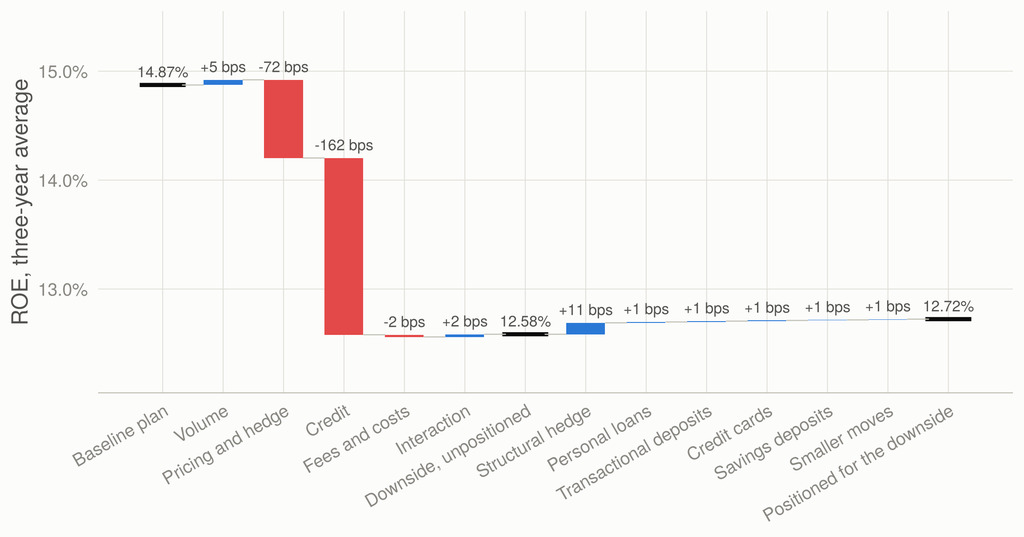

From the baseline plan to the downside, then to the downside positioned for it: three-year average ROE. Levels are marked with a bar; steps are labelled in basis points of ROE.

```r
bridge_plot("downside")
```

**Table view (1 bp of NIM-equivalent, pre-tax profit over interest-earning assets, = 9.7 bps of ROE)**

| Step | Kind | ROE | Net income, 3 years | NIM-equivalent |
| --- | --- | --- | --- | --- |
| Baseline plan | level | 14.87% | R52.6 bn | 154 bps |
| Volume | scenario | +4.7 bps | +R187 m | +0.5 bps |
| Pricing and hedge | scenario | -71.8 bps | -R2,817 m | -7.4 bps |
| Credit | scenario | -162.3 bps | -R6,328 m | -16.8 bps |
| Fees and costs | scenario | -2.0 bps | -R78 m | -0.2 bps |
| Interaction | scenario | +2.4 bps | +R157 m | +0.3 bps |
| Structural hedge | positioning | +10.5 bps | +R520 m | +1.1 bps |
| Personal loans | positioning | +0.8 bps | +R55 m | +0.1 bps |
| Transactional deposits | positioning | +0.8 bps | +R20 m | +0.1 bps |
| Credit cards | positioning | +0.6 bps | +R45 m | +0.1 bps |
| Savings deposits | positioning | +0.5 bps | +R14 m | +0.1 bps |
| Commercial property | positioning | +0.4 bps | +R4 m | +0.0 bps |
| Corporate loans | positioning | +0.2 bps | -R2 m | +0.0 bps |
| Residential mortgages | positioning | +0.1 bps | -R2 m | +0.0 bps |
| Term deposits | positioning | +0.0 bps | +R2 m | +0.0 bps |
| Vehicle and asset finance | positioning | +0.0 bps | -R1 m | +0.0 bps |
| Positioned for the downside | level | 12.72% | R44.4 bn | 132 bps |

Positioned, NGFB’s ROE in the downside is 12.7%: +14 bps better than unpositioned, or +R654 m of net income over three years, of which the hedge contributes +11 bps. That recovers 6% of the downside’s 229 bps hit: positioning cannot undo a credit cycle inside a year, and the bridge makes that visible, since the largest bar is credit and only the small unsecured trims are aimed at it.

**8. If the downside does not come.** The same moves cost 14 bps (-R493 m) if the baseline arrives instead and 35 bps (-R1,381 m) if the upside does.

**And if the SARB cuts instead?** In the variant with the same contraction but 150 bps of cuts, the optimal positioning reverses the hedge (+11.4 points of NMD instead of -7.3), shrinks deposits instead of growing them, and cuts every retail book, unsecured most (cards -0.31, personal loans -0.39). Positioning for the stagflationary downside when the cuts arrive costs 46 bps; positioning for the cuts when the hikes arrive costs 63 bps. The credit leg of a downside positioning is robust to the policy response; the rate leg is a bet on it.

## 11.5 The upside, step by step

**1. The macro path.** Inflation returns to the target sooner, the repo rate falls to 5.25% (1.00 pp below the baseline’s trough), growth averages 3.0% and house prices 7.8% a year.

**2–3. The industry and NGFB’s share.**

The sector’s projected paths in the upside against the baseline.

| Industry (Stage 1), three-year average | Baseline | Scenario | Change |
| --- | --- | --- | --- |
| Residential mortgages, growth (% a year) | 3.86 | 4.24 | +0.37 |
| Credit cards, growth | 7.78 | 9.39 | +1.61 |
| Personal loans, growth | 5.91 | 6.42 | +0.51 |
| Corporate loans, growth | 9.01 | 10.36 | +1.34 |
| Non-maturity deposits, growth | 7.13 | 7.77 | +0.64 |
| Credit-loss ratio (% of loans) | 0.88 | 0.78 | -0.10 |
| Cost of current accounts (%) | 3.33 | 2.89 | -0.45 |
| Cost of savings deposits (%) | 6.22 | 5.66 | -0.56 |
| Cost of fixed and notice deposits (%) | 7.02 | 6.09 | -0.93 |
| Home-loan yield less prime (pp) | -0.84 | -0.71 | +0.13 |
| Card yield less prime (pp) | 5.07 | 5.10 | +0.03 |
| Non-interest revenue (% of assets) | 2.24 | 2.28 | +0.04 |

Annualised growth over three years, percent, in the upside.

| Line | Sector growth | NGFB growth | NGFB share change (pp of growth) | Same, in the baseline |
| --- | --- | --- | --- | --- |
| Credit cards | 9.4 | 7.2 | -2.2 | -1.1 |
| Personal loans | 6.4 | 7.2 | +0.7 | +1.1 |
| Vehicle and asset finance | 9.1 | 8.2 | -0.9 | -0.8 |
| Residential mortgages | 4.2 | 4.5 | +0.3 | +0.3 |
| Corporate loans | 10.4 | 9.3 | -1.0 | -0.7 |
| Non-maturity deposits | 7.8 | 7.5 | -0.3 | +0.1 |

The upside has 8 easing, 4 neutral quarters. Lower rates cut deposit costs, credit losses fall by 0.10 pp of loans and volumes grow faster.

**4. NGFB without positioning.** ROE rises to 16.3% (+138 bps) and net income to R58.1 bn (+R5.5 bn): credit +99 bps, pricing and hedge +43 bps.

**5–6. Gradients and the solution.**

The upside positioning, move by move (units and conventions as for the downside).

| Move | G: engine gain per unit (bps) | c: implied cost (bps) | G - c (bps) | Execution cost (bps) | Move = (G - c) / 2 cost | Bounds | Contribution: ROE (bps) | Contribution: net income (R m) |
| --- | --- | --- | --- | --- | --- | --- | --- | --- |
| Residential mortgages | +38.0 | +39.1 | -1.1 | 8.0 | -0.07 | -2.0 to +2.0 | +0.1 | 0 |
| Vehicle and asset finance | +40.7 | +40.5 | +0.1 | 8.0 | +0.01 | -2.0 to +1.5 | 0.0 | +0 |
| Credit cards | +58.5 | +56.4 | +2.2 | 15.0 | +0.07 | -1.5 to +1.0 | +0.0 | +7 |
| Personal loans | +63.5 | +58.7 | +4.9 | 15.0 | +0.16 | -1.5 to +1.0 | +0.3 | +26 |
| Corporate loans | +44.7 | +45.9 | -1.3 | 8.0 | -0.08 | -2.0 to +2.0 | +0.1 | -1 |
| Commercial property | +32.2 | +34.5 | -2.3 | 8.0 | -0.14 | -1.5 to +1.5 | +0.2 | +3 |
| Term deposits | +6.9 | +7.1 | -0.2 | 4.0 | -0.02 | -2.0 to +2.0 | +0.0 | 0 |
| Savings deposits | +13.2 | +16.5 | -3.3 | 8.0 | -0.21 | -1.0 to +1.0 | +0.4 | +12 |
| Transactional deposits | +26.6 | +30.4 | -3.9 | 12.0 | -0.16 | -1.0 to +1.0 | +0.4 | +10 |
| Structural hedge | +10.4 | +8.1 | +2.3 | 0.2 | +5.72 | -25.0 to +25.0 | +6.3 | +332 |

The rows mirror the downside’s. The hedge is worth more than under the baseline (+10.4 bps against +8.1 bps a point), because its floating leg reprices down, so it is extended by 5.7 points, to 55.3% of NMD. Deposits are worth less as rates fall, so the bank lets 0.37% of assets of savings and transactional deposits go and funds with wholesale money; better credit makes unsecured lending worth more, so personal loans and cards grow by 0.23% of assets. Again no bound or floor binds.

**7–8. Re-run, bridge and the cost of being wrong.**

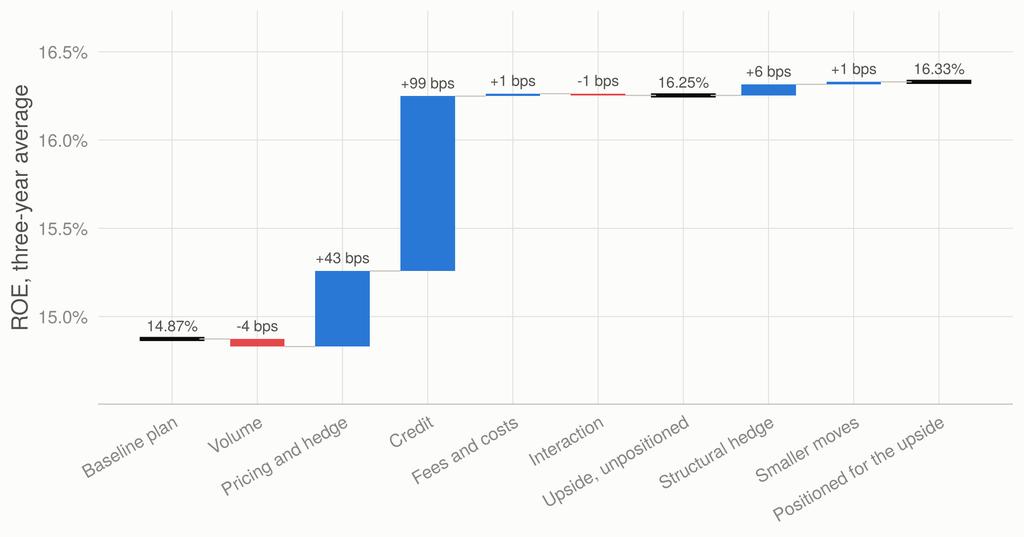

From the baseline plan to the upside, then to the upside positioned for it: three-year average ROE.

```r
bridge_plot("upside")
```

**Table view (1 bp of NIM-equivalent, pre-tax profit over interest-earning assets, = 9.7 bps of ROE)**

| Step | Kind | ROE | Net income, 3 years | NIM-equivalent |
| --- | --- | --- | --- | --- |
| Baseline plan | level | 14.87% | R52.6 bn | 154 bps |
| Volume | scenario | -4.3 bps | -R170 m | -0.4 bps |
| Pricing and hedge | scenario | +42.8 bps | +R1,696 m | +4.4 bps |
| Credit | scenario | +99.0 bps | +R3,938 m | +10.3 bps |
| Fees and costs | scenario | +1.4 bps | +R55 m | +0.1 bps |
| Interaction | scenario | -1.0 bps | -R17 m | -0.1 bps |
| Structural hedge | positioning | +6.3 bps | +R332 m | +0.6 bps |
| Personal loans | positioning | +0.3 bps | +R26 m | +0.0 bps |
| Savings deposits | positioning | +0.4 bps | +R12 m | +0.0 bps |
| Transactional deposits | positioning | +0.4 bps | +R10 m | +0.0 bps |
| Commercial property | positioning | +0.2 bps | +R3 m | +0.0 bps |
| Credit cards | positioning | +0.0 bps | +R7 m | +0.0 bps |
| Corporate loans | positioning | +0.1 bps | -R1 m | +0.0 bps |
| Residential mortgages | positioning | +0.1 bps | +R0 m | +0.0 bps |
| Term deposits | positioning | +0.0 bps | +R0 m | +0.0 bps |
| Vehicle and asset finance | positioning | +0.0 bps | +R0 m | 0.0 bps |
| Positioned for the upside | level | 16.33% | R58.5 bn | 169 bps |

Positioned, NGFB earns 16.3% in the upside, +8 bps more (+R388 m of net income). The same moves cost 8 bps if the baseline arrives and 29 bps (-R1,121 m) if the downside does.